# PREDICCIÓN DEL VOLUMEN DE VENTAS E IMPACTO DE LAS RESEÑAS

Javier Paneque Linares

10/12/2021

# 1 CONOCIMIENTO DEL PROBLEMA

El equipo de ventas ha seguido de cerca el rendimiento en ventas de distintos tipos de productos y les gustaría que analizaramos y predijéramos por qué y cómo se ve afectado cada producto.

Danielle Sherman, CTO of Blackwell Electronics nos pide analizar los datos históricos de ventas y predecir el volumen de ventas para una lista de nuevos productos. Esto ayudará al equipo de ventas a comprender mejor cómo los tipos de productos pueden ver afectadas sus ventas en toda la empresa.

Los objetivos son:

- **Predecir las ventas de los siguientes productos: Ordenadores, portátiles, netbooks y teléfonos móviles.**
- **Evaluar el impacto en ventas que tienen las reseñas de los clientes sobre los productos y servicios.**

# 2 RECOLECCIÓN DE LOS DATOS

La recolección de datos históricos nos proporciona la información que necesitamos. Nos adjuntan dos archivos:

- **existingproductattributes2017.csv**: contiene datos históricos de ventas de los productos.
- **newproductattributes2017.csv**: contiene datos de nuevos productos cuyo volumen de ventas debemos de predecir.

## 2.1 CARGADO DE LOS DATOS

Se cargan los datos, concretamente los archivos *existingproductattributes2017.csv* y *newproductattributes2017.csv*:

```r
#Se cargan los datos
EPA <- read.csv("existingproductattributes2017.csv")
NPA <- read.csv("newproductattributes2017.csv")
#Número de datos que tenemos
sprintf("Número de productos registrados en los datos históricos: %s",length(EPA[,1]))
```

```
## [1] "Número de productos registrados en los datos históricos: 80"
```

```r
sprintf("Número de nuevos productos: %s",length(NPA[,1]))
```

```
## [1] "Número de nuevos productos: 24"
```

## 2.2 DESCRIPCIÓN DE LAS VARIABLES

Se describen las variables que nos han proporcionado.

- Variables que contiene el conjunto de datos:
  - **ProductType**: Tipo de producto. Existen las siguientes categorias:
    - PC
    - Laptop
    - Accessories
    - Software
    - Display
    - Printer
    - PrinterSupplies
    - ExtendedWarranty
    - Netbook
    - Tablet
    - Smartphone
    - GameConsole
  - **ProductNum**: Número identificativo del producto.
  - **Price**: Precio del producto.
  - **x5StarReviews**: Reseñas puntuadas con 5 estrellas.
  - **x4StarReviews**: Reseñas puntuadas con 4 estrellas.
  - **x3StarReviews**: Reseñas puntuadas con 3 estrellas.
  - **x2StarReviews**: Reseñas puntuadas con 2 estrellas.
  - **x1StarReviews**: Reseñas puntuadas con 1 estrella.
  - **PositiveServiceReview**: Número de reseñas positivas referentes al servicio.
  - **NegativeServiceReview**: Número de reseñas negativas referentes al servicio.
  - **RecommendProduct**: Valoración en la recomendación del producto.
  - **BestSellerRank**: Posición en el ranking de más vendidos.
  - **ShippingWeight**: Peso del producto que figura en el envio.
  - **ProductDepth**: Longitud de la profundidad del producto.
  - **ProductWidth**: Longitud de la anchura del producto.
  - **ProductHeight**: Longitud de la altura del producto.
  - **ProfitMargin**: Fracción del margen de beneficio.
  - **Volume**: Volumen de ventas.
- Tipo variables
  - Datos Históricos:

```r
#Se comprueba el tipo de variable que contiene
str(EPA)
```

```
## 'data.frame':    80 obs. of  18 variables:
##  $ ProductType          : chr  "PC" "PC" "PC" "Laptop" ...
##  $ ProductNum           : int  101 102 103 104 105 106 107 108 109 110 ...
##  $ Price                : num  949 2250 399 410 1080 ...
##  $ x5StarReviews        : int  3 2 3 49 58 83 11 33 16 10 ...
##  $ x4StarReviews        : int  3 1 0 19 31 30 3 19 9 1 ...
##  $ x3StarReviews        : int  2 0 0 8 11 10 0 12 2 1 ...
##  $ x2StarReviews        : int  0 0 0 3 7 9 0 5 0 0 ...
##  $ x1StarReviews        : int  0 0 0 9 36 40 1 9 2 0 ...
##  $ PositiveServiceReview: int  2 1 1 7 7 12 3 5 2 2 ...
##  $ NegativeServiceReview: int  0 0 0 8 20 5 0 3 1 0 ...
##  $ Recommendproduct     : num  0.9 0.9 0.9 0.8 0.7 0.3 0.9 0.7 0.8 0.9 ...
##  $ BestSellersRank      : int  1967 4806 12076 109 268 64 NA 2 NA 18 ...
##  $ ShippingWeight       : num  25.8 50 17.4 5.7 7 1.6 7.3 12 1.8 0.75 ...
##  $ ProductDepth         : num  23.9 35 10.5 15 12.9 ...
##  $ ProductWidth         : num  6.62 31.75 8.3 9.9 0.3 ...
##  $ ProductHeight        : num  16.9 19 10.2 1.3 8.9 ...
##  $ ProfitMargin         : num  0.15 0.25 0.08 0.08 0.09 0.05 0.05 0.05 0.05 0.05 ...
##  $ Volume               : int  12 8 12 196 232 332 44 132 64 40 ...
```

- Nuevos Productos:

```r
#Se comprueba el tipo de variable que contiene
str(NPA)
```

```
## 'data.frame':    24 obs. of  18 variables:
##  $ ProductType          : chr  "PC" "PC" "Laptop" "Laptop" ...
##  $ ProductNum           : int  171 172 173 175 176 178 180 181 183 186 ...
##  $ Price                : num  699 860 1199 1199 1999 ...
##  $ x5StarReviews        : int  96 51 74 7 1 19 312 23 3 296 ...
##  $ x4StarReviews        : int  26 11 10 2 1 8 112 18 4 66 ...
##  $ x3StarReviews        : int  14 10 3 1 1 4 28 7 0 30 ...
##  $ x2StarReviews        : int  14 10 3 1 3 1 31 22 1 21 ...
##  $ x1StarReviews        : int  25 21 11 1 0 10 47 18 0 36 ...
##  $ PositiveServiceReview: int  12 7 11 2 0 2 28 5 1 28 ...
##  $ NegativeServiceReview: int  3 5 5 1 1 4 16 16 0 9 ...
##  $ Recommendproduct     : num  0.7 0.6 0.8 0.6 0.3 0.6 0.7 0.4 0.7 0.8 ...
##  $ BestSellersRank      : int  2498 490 111 4446 2820 4140 2699 1704 5128 34 ...
##  $ ShippingWeight       : num  19.9 27 6.6 13 11.6 5.8 4.6 4.8 4.3 3 ...
##  $ ProductDepth         : num  20.63 21.89 8.94 16.3 16.81 ...
##  $ ProductWidth         : num  19.2 27 12.8 10.8 10.9 ...
##  $ ProductHeight        : num  8.39 9.13 0.68 1.4 0.88 1.2 0.95 1.5 0.97 0.37 ...
##  $ ProfitMargin         : num  0.25 0.2 0.1 0.15 0.23 0.08 0.09 0.11 0.09 0.1 ...
##  $ Volume               : int  0 0 0 0 0 0 0 0 0 0 ...
```

# 3 PREPARACIÓN DE LOS DATOS

En este apartado se manipularán los datos para evitar problemas de formato o valores incorrectos que induzcan a error, etc.

## 3.1 LIMPIEZA DE DATOS

En primer lugar limpiamos los datos.

### 3.1.1 VALORES INCORRECTOS

Aquí tratamos de identificar los valores fuera de rango o valores que no tengan sentido para nuestras variables.

Mostramos un resumen estadístico de los datos:

- Datos Históricos

```r
#Resumen de los principales estadísticos
summary(EPA)
```

```
##  ProductType          ProductNum        Price         x5StarReviews
##  Length:80          Min.   :101.0   Min.   :   3.60   Min.   :   0.0
##  Class :character   1st Qu.:120.8   1st Qu.:  52.66   1st Qu.:  10.0
##  Mode  :character   Median :140.5   Median : 132.72   Median :  50.0
##                     Mean   :142.6   Mean   : 247.25   Mean   : 176.2
##                     3rd Qu.:160.2   3rd Qu.: 352.49   3rd Qu.: 306.5
##                     Max.   :200.0   Max.   :2249.99   Max.   :2801.0
##
##  x4StarReviews    x3StarReviews    x2StarReviews    x1StarReviews
##  Min.   :  0.00   Min.   :  0.00   Min.   :  0.00   Min.   :   0.00
##  1st Qu.:  2.75   1st Qu.:  2.00   1st Qu.:  1.00   1st Qu.:   2.00
##  Median : 22.00   Median :  7.00   Median :  3.00   Median :   8.50
##  Mean   : 40.20   Mean   : 14.79   Mean   : 13.79   Mean   :  37.67
##  3rd Qu.: 33.00   3rd Qu.: 11.25   3rd Qu.:  7.00   3rd Qu.:  15.25
##  Max.   :431.00   Max.   :162.00   Max.   :370.00   Max.   :1654.00
##
##  PositiveServiceReview NegativeServiceReview Recommendproduct BestSellersRank
##  Min.   :  0.00        Min.   :  0.000       Min.   :0.100    Min.   :    1
##  1st Qu.:  2.00        1st Qu.:  1.000       1st Qu.:0.700    1st Qu.:    7
##  Median :  5.50        Median :  3.000       Median :0.800    Median :   27
##  Mean   : 51.75        Mean   :  6.225       Mean   :0.745    Mean   : 1126
##  3rd Qu.: 42.00        3rd Qu.:  6.250       3rd Qu.:0.900    3rd Qu.:  281
##  Max.   :536.00        Max.   :112.000       Max.   :1.000    Max.   :17502
##                                                               NA's   :15
##  ShippingWeight     ProductDepth      ProductWidth    ProductHeight
##  Min.   : 0.0100   Min.   :  0.000   Min.   : 0.000   Min.   : 0.000
##  1st Qu.: 0.5125   1st Qu.:  4.775   1st Qu.: 1.750   1st Qu.: 0.400
##  Median : 2.1000   Median :  7.950   Median : 6.800   Median : 3.950
##  Mean   : 9.6681   Mean   : 14.425   Mean   : 7.819   Mean   : 6.259
##  3rd Qu.:11.2050   3rd Qu.: 15.025   3rd Qu.:11.275   3rd Qu.:10.300
##  Max.   :63.0000   Max.   :300.000   Max.   :31.750   Max.   :25.800
##
##   ProfitMargin        Volume
##  Min.   :0.0500   Min.   :    0
##  1st Qu.:0.0500   1st Qu.:   40
##  Median :0.1200   Median :  200
##  Mean   :0.1545   Mean   :  705
##  3rd Qu.:0.2000   3rd Qu.: 1226
##  Max.   :0.4000   Max.   :11204
##
```

- Nuevos Productos

```r
#Resumen de los principales estadísticos
summary(NPA)
```

```
##  ProductType          ProductNum        Price        x5StarReviews
##  Length:24          Min.   :171.0   Min.   :   8.5   Min.   :   0.00
##  Class :character   1st Qu.:179.5   1st Qu.: 130.0   1st Qu.:  16.00
##  Mode  :character   Median :193.5   Median : 275.0   Median :  46.00
##                     Mean   :219.5   Mean   : 425.6   Mean   : 178.50
##                     3rd Qu.:301.2   3rd Qu.: 486.5   3rd Qu.:  99.25
##                     Max.   :307.0   Max.   :1999.0   Max.   :1525.00
##  x4StarReviews    x3StarReviews    x2StarReviews    x1StarReviews
##  Min.   :  0.00   Min.   :  0.00   Min.   :  0.00   Min.   :  0.00
##  1st Qu.:  2.00   1st Qu.:  1.75   1st Qu.:  1.00   1st Qu.:  1.75
##  Median : 10.50   Median :  4.50   Median :  4.00   Median : 13.00
##  Mean   : 48.04   Mean   : 21.92   Mean   : 17.50   Mean   : 27.58
##  3rd Qu.: 26.00   3rd Qu.: 16.75   3rd Qu.: 20.25   3rd Qu.: 35.25
##  Max.   :437.00   Max.   :224.00   Max.   :160.00   Max.   :247.00
##  PositiveServiceReview NegativeServiceReview Recommendproduct
##  Min.   : 0.00         Min.   : 0.000        Min.   :0.3000
##  1st Qu.: 2.00         1st Qu.: 1.000        1st Qu.:0.6000
##  Median : 5.00         Median : 3.500        Median :0.7000
##  Mean   :13.46         Mean   : 5.667        Mean   :0.6708
##  3rd Qu.:12.50         3rd Qu.: 7.500        3rd Qu.:0.8000
##  Max.   :90.00         Max.   :23.000        Max.   :1.0000
##  BestSellersRank    ShippingWeight    ProductDepth     ProductWidth
##  Min.   :    1.00   Min.   : 0.200   Min.   : 0.000   Min.   : 0.000
##  1st Qu.:   93.25   1st Qu.: 0.900   1st Qu.: 5.225   1st Qu.: 5.832
##  Median :  750.50   Median : 4.450   Median : 8.000   Median : 9.950
##  Mean   : 3957.62   Mean   : 7.802   Mean   : 9.094   Mean   :10.408
##  3rd Qu.: 3150.00   3rd Qu.: 9.575   3rd Qu.:11.425   3rd Qu.:12.875
##  Max.   :44465.00   Max.   :42.000   Max.   :21.890   Max.   :27.010
##  ProductHeight     ProfitMargin        Volume
##  Min.   : 0.000   Min.   :0.0500   Min.   :0
##  1st Qu.: 0.400   1st Qu.:0.0975   1st Qu.:0
##  Median : 0.985   Median :0.1150   Median :0
##  Mean   : 3.541   Mean   :0.1817   Mean   :0
##  3rd Qu.: 2.888   3rd Qu.:0.2000   3rd Qu.:0
##  Max.   :25.800   Max.   :0.9000   Max.   :0
```

Observamos que todas las variables están dentro de los rangos esperados con las siguientes excepciones:

- La variable *BestSellerRank* muestra 15 missing values de un total de 80 datos, cerca del 20%.
- Algunos productos tienen una longitud de profundidad, altura y anchura igual a cero. Se verifica que estos valores se corresponden a productos no físicos.
- La suma total de reseñas es, en ocasiones, mayor al volumen total de ventas. Podría tratarse de productos que han sido devueltos, no se realizará ninguna acción sobre este hecho.

### 3.1.2 VALORES DUPLICADOS

Revisamos si existen valores duplicados para ambos conjuntos de datos:

```r
#Datos duplicados
sprintf('Datos duplicados para Datos Históricos: %s',unique(duplicated(EPA)))
```

```
## [1] "Datos duplicados para Datos Históricos: FALSE"
```

```r
sprintf('Datos duplicados para Nuevos Productos: %s',unique(duplicated(NPA)))
```

```
## [1] "Datos duplicados para Nuevos Productos: FALSE"
```

No tenemos ninguna fila repetida.

#### 3.1.2.1 NÚMERO DE PRODUCTO

A pesar de no haber datos duplicados, debemos hacer una revisión adicional. El número de producto identifica de qué producto se trata. Por esta razón, este valor no se debe repetir ni dentro un mismo conjunto de datos ni en el global. Comprobamos que se cumple esta condición.

```r
sprintf('Producto duplicado para Datos Históricos: %s',unique(duplicated(EPA$ProductNum)))
```

```
## [1] "Producto duplicado para Datos Históricos: FALSE"
```

```r
sprintf('Producto duplicado para Nuevos Productos: %s',unique(duplicated(NPA$ProductNum)))
```

```
## [1] "Producto duplicado para Nuevos Productos: FALSE"
```

```r
sprintf('Producto duplicado para el Global de Todos los Datos: %s',
        c(EPA$ProductNum, NPA$ProductNum) %>% duplicated() %>% unique())
```

```
## [1] "Producto duplicado para el Global de Todos los Datos: FALSE"
```

No hay duplicidad en los productos.

### 3.1.3 VALORES ATÍPICOS

Es necesario conocer la distribución de los datos para identificar los valores atípicos. Por este motivo, los valoraremos durante el análisis exploratorio.

### 3.1.4 CAMBIO DE CLASE

Tenemos varias variables categóricas que se describen mediante valores enteros. Vamos a modificar la clase de estas variables a variables tipo factor.

```r
#Vector nombres tipo producto
tipo_name <- c('PC','Laptop','Netbook','Smartphone','Accessories','Software',
               'Display','Printer','PrinterSupplies','ExtendedWarranty',
               'Tablet','GameConsole')
#Se reconvierte la variable tipo de producto en clase factor
EPA$ProductType <- factor(EPA$ProductType,levels=tipo_name)
NPA$ProductType <- factor(NPA$ProductType,levels=tipo_name)
#Se reconvierte la variable número de producto en clase factor
EPA$ProductNum <- factor(EPA$ProductNum)
NPA$ProductNum <- factor(NPA$ProductNum)
```

Convertimos las variables categóricas en binarias 0-1:

```r
#dummify the data
EPA <- dummyVars(" ~ .", data = EPA['ProductType']) %>% predict(newdata = EPA['ProductType']) %>% data.frame() %>% cbind(EPA)
#dummify the data
NPA <- dummyVars(" ~ .", data = NPA['ProductType']) %>% predict(newdata = NPA['ProductType']) %>% data.frame() %>% cbind(NPA)
```

## 3.2 RENOMBRAR VARIABLES

Cambiamos el nombre de las variables:

```r
#Vectores nombres
Nuevos_Nombres <- c('PC','Laptop','Accessories','Software','Display',
                    'Printer','Supplies','Warranty','Netbook','Tablet',
                    'Smartphone','GC','Tipo','ID','Precio','Star5','Star4',
                    'Star3','Star2','Star1','SerPos','SerNeg','Reco','Ranking',
                    'Peso','Prof','Ancho','Alto','Beneficio','Volumen')
Ordenar_Nombres <- c('Volumen','Star5','Star4','Star3','Star2','Star1',
                     'SerPos','SerNeg','Precio','Reco','Ranking','Peso',
                     'Prof','Ancho','Alto','Beneficio','Tipo','PC','Laptop',
                     'Netbook','Smartphone','Display','Printer','Supplies',
                     'Warranty','Tablet','Software','Accessories','GC','ID')
#Cambiamos nombres
names(EPA) <- Nuevos_Nombres
names(NPA) <- Nuevos_Nombres
#Ordenamos columnas
EPA <- EPA[Ordenar_Nombres]
NPA <- NPA[Ordenar_Nombres]
```

# 4 ANÁLISIS EXPLORATORIO

El objetivo es describir las variables mostrando cómo se distribuyen y qué relaciones existen entre ellas.

## 4.1 ANÁLISIS UNIVARIANTE

Empecemos por el primer punto: ¿cómo se distribuyen las variables?

### 4.1.1 TIPO DE PRODUCTO

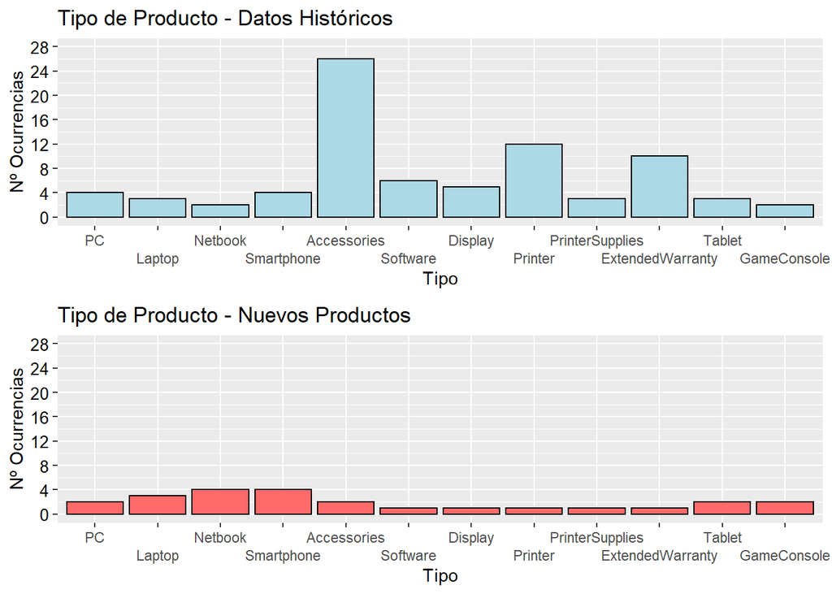

Figure 1: Distribución de la variable Tipo de Producto

```r
#Barplot plot Tipo EPA
EPA_Tipo <- ggplot(EPA, aes(x=Tipo,y=..count..))+
  geom_bar(color="black",fill='lightblue')+
  ggtitle('Tipo de Producto - Datos Históricos')+
  scale_x_discrete(guide=guide_axis(n.dodge=2))+
  theme(axis.text.y = element_text(color='black',size=10,angle=0))+
  scale_y_continuous(name ="Nº Ocurrencias",limits=c(0,28),breaks=seq(0,28,4))
#Barplot plot Tipo NPA
NPA_Tipo <- ggplot(NPA, aes(x=Tipo,y=..count..))+
  geom_bar(color="black",fill='indianred1')+
  ggtitle('Tipo de Producto - Nuevos Productos')+
  scale_x_discrete(guide=guide_axis(n.dodge=2))+
  theme(axis.text.y = element_text(color='black',size=10,angle=0))+
  scale_y_continuous(name ="Nº Ocurrencias",limits=c(0,28),breaks=seq(0,28,4))
#Se muestra el gráfico
grid.arrange(EPA_Tipo,NPA_Tipo, nrow=2)
```

### 4.1.2 NÚMERO DE PRODUCTO

Esta variable es un identificador y única para cada producto por lo que no tiene sentido revisar su distribución.

### 4.1.3 PRECIO

Mostramos la distribución de la variable precio:

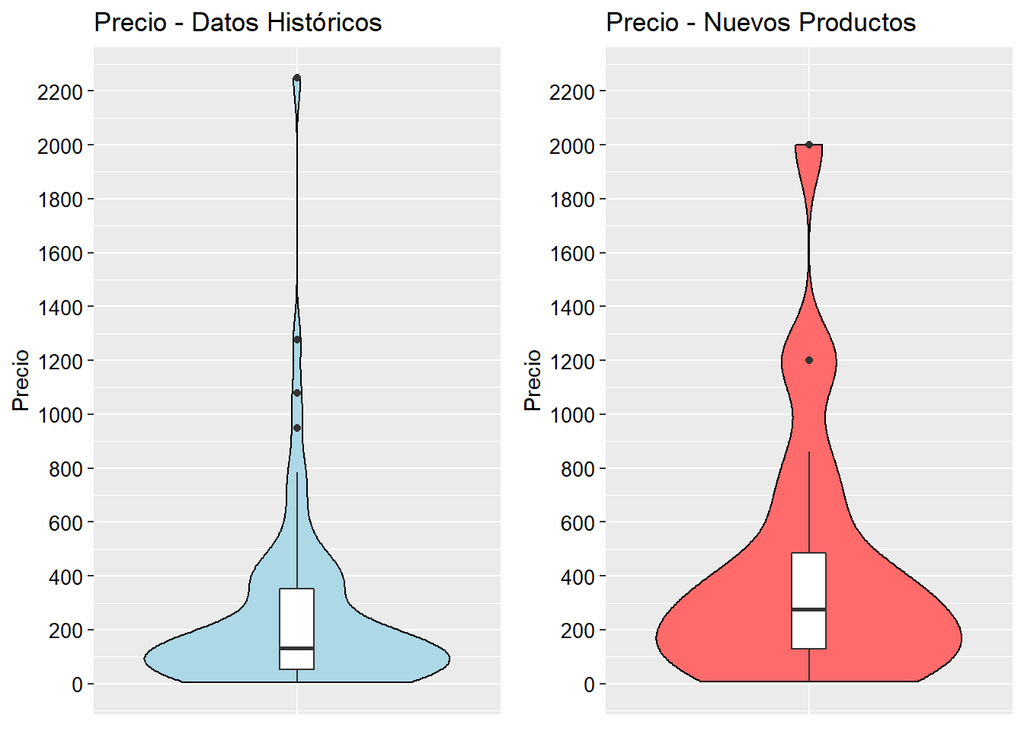

Figure 2: Distribución de la variable Precio

```r
#Violin plot Precio EPA
EPA_Precio <- ggplot(EPA, aes(x=factor(0),y=Precio))+
  geom_violin(color="black",fill='lightblue')+
  geom_boxplot(width=0.1)+
  ggtitle('Precio - Datos Históricos')+
  theme(axis.text.x=element_blank(),
        axis.ticks.x=element_blank(),
        axis.title.x=element_blank(),
        axis.text.y = element_text(color='black',size=10,angle=0))+
  scale_y_continuous(name ="Precio",limits=c(0,2250),breaks=seq(0,2250,200))
#Violin plot Precio NPA
NPA_Precio <- ggplot(NPA, aes(x=factor(0),y=Precio))+
  geom_violin(color="black",fill='indianred1')+
  geom_boxplot(width=0.1)+
  ggtitle('Precio - Nuevos Productos')+
  theme(axis.text.x=element_blank(),
        axis.ticks.x=element_blank(),
        axis.title.x=element_blank(),
        axis.text.y = element_text(color='black',size=10,angle=0))+
  scale_y_continuous(name ="Precio",limits=c(0,2250),breaks=seq(0,2250,200))
#Se muestra el gráfico
grid.arrange(EPA_Precio,NPA_Precio, ncol=2)
```

Los nuevos productos tienen unos precios distribuidos alrededor de una mediana más alta.

### 4.1.4 RESEÑAS

Mostramos la distribución del número de reseñas recibidas:

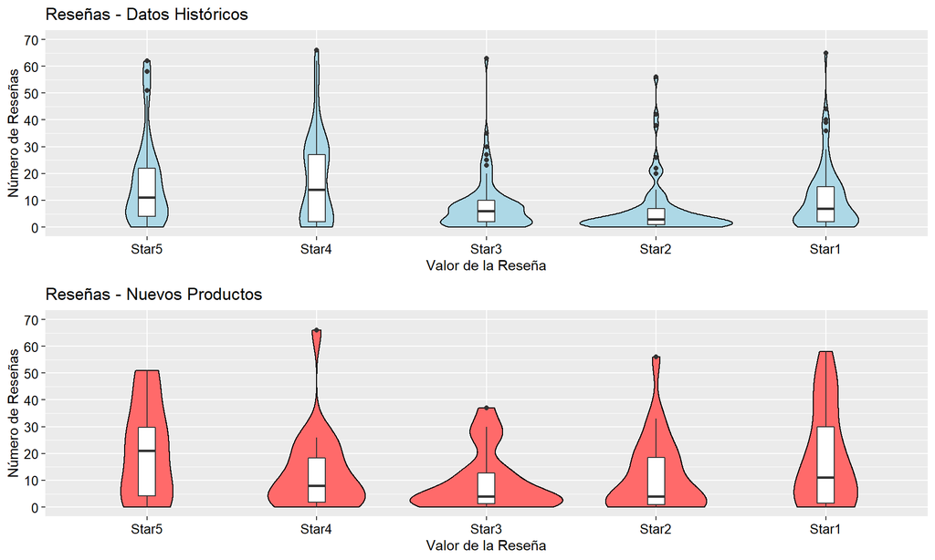

Figure 3: Distribución de la variable Reseña

```r
#Violin plot Reseña EPA
EPA_Reseña <- gather(EPA,Star,N,Star5,Star4,Star3,Star2,Star1,factor_key = TRUE) %>%
              ggplot(aes(x=Star,y=N))+
  geom_violin(color="black",fill='lightblue')+
  geom_boxplot(width=0.1)+
  ggtitle('Reseñas - Datos Históricos')+
  theme(axis.text.x = element_text(color='black',size=10,angle=0),
        axis.text.y = element_text(color='black',size=10,angle=0))+
  scale_y_continuous(name ="Número de Reseñas",limits=c(0,70),breaks=seq(0,70,10))+
  scale_x_discrete(name ="Valor de la Reseña")
#Violin plot Reseña NPA
NPA_Reseña <- gather(NPA,Star,N,Star5,Star4,Star3,Star2,Star1,factor_key = TRUE) %>%
              ggplot(aes(x=Star,y=N))+
  geom_violin(color="black",fill='indianred1')+
  geom_boxplot(width=0.1)+
  ggtitle('Reseñas - Nuevos Productos')+
  theme(axis.text.x = element_text(color='black',size=10,angle=0),
        axis.text.y = element_text(color='black',size=10,angle=0))+
  scale_y_continuous(name ="Número de Reseñas",limits=c(0,70),breaks=seq(0,70,10))+
  scale_x_discrete(name ="Valor de la Reseña")
#Se muestra el gráfico
grid.arrange(EPA_Reseña,NPA_Reseña, nrow=2)
```

Se observan claros outliers en todas las variables referentes a reseñas.

Se decide manipular estas variables para sintetizar su información en dos nuevas variables: el valor medio de las reseñas y el número total de estas. A continuación se muestra la distribución de estas nuevas variables.

```r
#Se calcula la reseña media
EPA$StarM <- EPA %>% with((Star5*5+Star4*4+Star3*3+Star2*2+Star1)/(Star5+Star4+Star3+Star2+Star1))
NPA$StarM <- NPA %>% with((Star5*5+Star4*4+Star3*3+Star2*2+Star1)/(Star5+Star4+Star3+Star2+Star1))
#Se calcula el número de reseñas totales
EPA$NRes <- EPA %>% with(Star5+Star4+Star3+Star2+Star1)
NPA$NRes <- NPA %>% with(Star5+Star4+Star3+Star2+Star1)
```

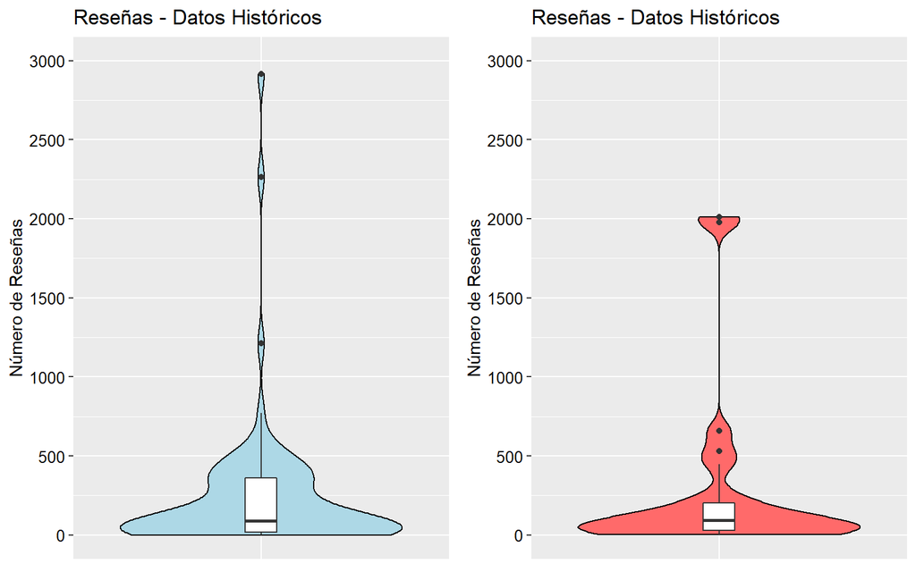

Figure 4: Distribución del número total de reseñas

```r
#Violin plot N Reseñas EPA
EPA_NReseñas <- ggplot(EPA,aes(x=factor(0),y=NRes))+
  geom_violin(color="black",fill='lightblue')+
  geom_boxplot(width=0.1)+
  ggtitle('Reseñas - Datos Históricos')+
  theme(axis.text.x=element_blank(),
        axis.ticks.x=element_blank(),
        axis.title.x=element_blank(),
        axis.text.y = element_text(color='black',size=10,angle=0))+
  scale_y_continuous(name ="Número de Reseñas",limits=c(0,3000),breaks=seq(0,3000,500))
#Violin plot N Reseñas NPA
NPA_NReseñas <- ggplot(NPA,aes(x=factor(0),y=NRes))+
  geom_violin(color="black",fill='indianred1')+
  geom_boxplot(width=0.1)+
  ggtitle('Reseñas - Datos Históricos')+
  theme(axis.text.x=element_blank(),
        axis.ticks.x=element_blank(),
        axis.title.x=element_blank(),
        axis.text.y = element_text(color='black',size=10,angle=0))+
  scale_y_continuous(name ="Número de Reseñas",limits=c(0,3000),breaks=seq(0,3000,500))
#Se muestra el gráfico
grid.arrange(EPA_NReseñas,NPA_NReseñas, ncol=2)
```

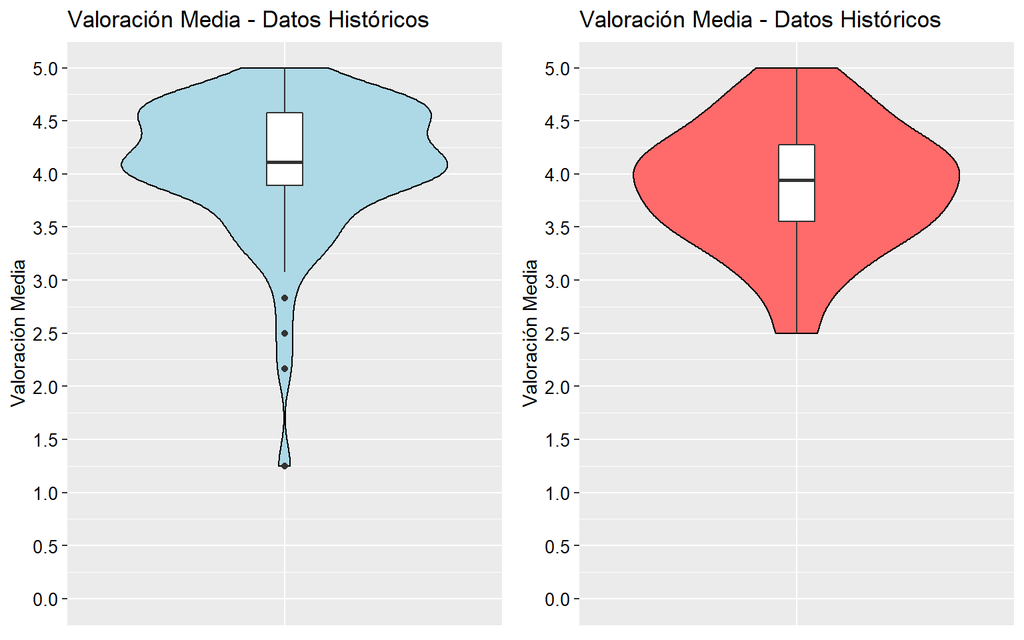

Figure 5: Distribución de la valoración media del producto

```r
#Violin plot N Reseñas EPA
EPA_StarM <- ggplot(EPA,aes(x=factor(0),y=StarM))+
  geom_violin(color="black",fill='lightblue')+
  geom_boxplot(width=0.1)+
  ggtitle('Valoración Media - Datos Históricos')+
  theme(axis.text.x=element_blank(),
        axis.ticks.x=element_blank(),
        axis.title.x=element_blank(),
        axis.text.y = element_text(color='black',size=10,angle=0))+
  scale_y_continuous(name ="Valoración Media",limits=c(0,5),breaks=seq(0,5,0.5))
#Violin plot N Reseñas NPA
NPA_StarM <- ggplot(NPA,aes(x=factor(0),y=StarM))+
  geom_violin(color="black",fill='indianred1')+
  geom_boxplot(width=0.1)+
  ggtitle('Valoración Media - Datos Históricos')+
  theme(axis.text.x=element_blank(),
        axis.ticks.x=element_blank(),
        axis.title.x=element_blank(),
        axis.text.y = element_text(color='black',size=10,angle=0))+
  scale_y_continuous(name ="Valoración Media",limits=c(0,5),breaks=seq(0,5,0.5))
#Se muestra el gráfico
grid.arrange(EPA_StarM,NPA_StarM, ncol=2)
```

De nuevo tenemos algunos outliers, debemos tener en cuenta estos valores atípicos en el modelado ya que pueden tener un alto impacto en las predicciones finales.

### 4.1.5 RESEÑAS DEL SERVICIO

Mostramos la distribución del número de reseñas del servicio recibidas:

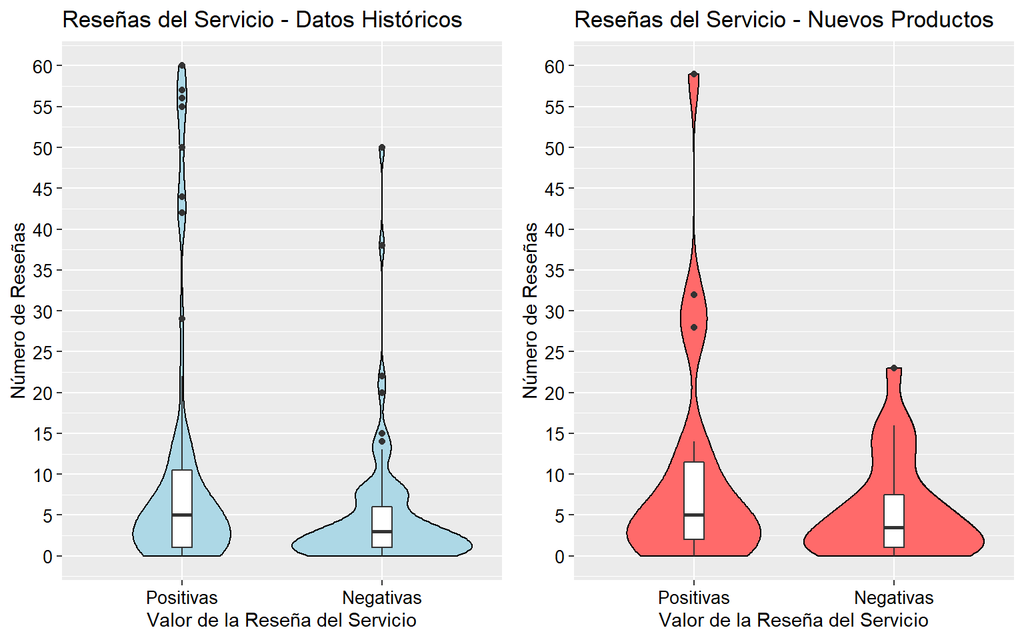

Figure 6: Distribución de la variable Reseña del Servicio

```r
#Violin plot Reseña del Servicio EPA
EPA_ReseñaServicio <- gather(EPA,RSP,N,SerPos,SerNeg,factor_key = TRUE) %>%
              ggplot(aes(x=RSP,y=N))+
  geom_violin(color="black",fill='lightblue')+
  geom_boxplot(width=0.1)+
  ggtitle('Reseñas del Servicio - Datos Históricos')+
  theme(axis.text.x = element_text(color='black',size=10,angle=0),
        axis.text.y = element_text(color='black',size=10,angle=0))+
  scale_y_continuous(name ="Número de Reseñas",limits=c(0,60),breaks=seq(0,60,5))+
  scale_x_discrete(name ="Valor de la Reseña del Servicio",
                   labels=c('Positivas','Negativas'))
#Violin plot Reseña del Servicio NPA
NPA_ReseñaServicio <- gather(NPA,RSP,N,SerPos,SerNeg,factor_key = TRUE) %>%
              ggplot(aes(x=RSP,y=N))+
  geom_violin(color="black",fill='indianred1')+
  geom_boxplot(width=0.1)+
  ggtitle('Reseñas del Servicio - Nuevos Productos')+
  theme(axis.text.x = element_text(color='black',size=10,angle=0),
        axis.text.y = element_text(color='black',size=10,angle=0))+
  scale_y_continuous(name ="Número de Reseñas",limits=c(0,60),breaks=seq(0,60,5))+
  scale_x_discrete(name ="Valor de la Reseña del Servicio",
                   labels=c('Positivas','Negativas'))
#Se muestra el gráfico
grid.arrange(EPA_ReseñaServicio,NPA_ReseñaServicio, ncol=2)
```

Distribuciones parecidas para ambos conjuntos de datos. La distribución muestra un alto *skew*. Varios valores atípicos.

### 4.1.6 GRADO DE RECOMENDACIÓN

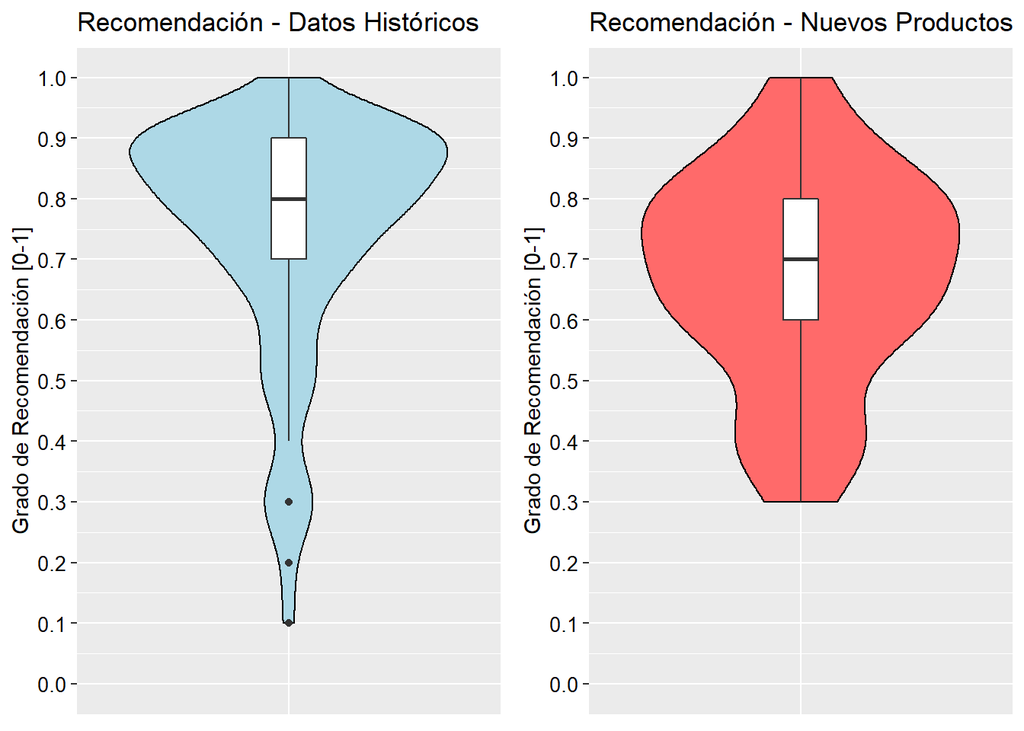

Figure 7: Distribución del Grado de Recomendación

```r
#Violin plot Recomendación EPA
EPA_Recomendacion <- ggplot(EPA,aes(x=factor(0),y=Reco))+
  geom_violin(color="black",fill='lightblue')+
  geom_boxplot(width=0.1)+
  ggtitle('Recomendación - Datos Históricos')+
  theme(axis.text.x=element_blank(),
        axis.ticks.x=element_blank(),
        axis.title.x=element_blank(),
        axis.text.y = element_text(color='black',size=10,angle=0))+
  scale_y_continuous(name ="Grado de Recomendación [0-1]",limits=c(0,1),breaks=seq(0,1,0.1))
#Violin plot Reseña Media NPA
NPA_Recomendacion <- ggplot(NPA,aes(x=factor(0),y=Reco))+
  geom_violin(color="black",fill='indianred1')+
  geom_boxplot(width=0.1)+
  ggtitle('Recomendación - Nuevos Productos')+
  theme(axis.text.x=element_blank(),
        axis.ticks.x=element_blank(),
        axis.title.x=element_blank(),
        axis.text.y = element_text(color='black',size=10,angle=0))+
  scale_y_continuous(name ="Grado de Recomendación [0-1]",limits=c(0,1),breaks=seq(0,1,0.1))
#Se muestra el gráfico
grid.arrange(EPA_Recomendacion,NPA_Recomendacion, ncol=2)
```

Los nuevos productos muestran una distribución más simétrica, parecida a una distribución normal. De nuevo tenemos valores atípicos en los datos históricos.

### 4.1.7 RANKING DE MEJOR VENDIDOS

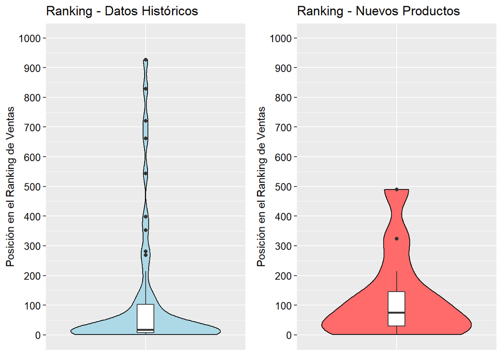

Figure 8: Distribución de la Posición en el Ranking de Ventas

```r
#Violin plot Ranking EPA
EPA_Ranking <- ggplot(EPA,aes(x=factor(0),y=Ranking))+
  geom_violin(color="black",fill='lightblue')+
  geom_boxplot(width=0.1)+
  ggtitle('Ranking - Datos Históricos')+
  theme(axis.text.x=element_blank(),
        axis.ticks.x=element_blank(),
        axis.title.x=element_blank(),
        axis.text.y = element_text(color='black',size=10,angle=0))+
  scale_y_continuous(name ="Posición en el Ranking de Ventas",limits=c(0,1000),breaks=seq(0,1000,100))
#Violin plot Ranking NPA
NPA_Ranking <- ggplot(NPA,aes(x=factor(0),y=Ranking))+
  geom_violin(color="black",fill='indianred1')+
  geom_boxplot(width=0.1)+
  ggtitle('Ranking - Nuevos Productos')+
  theme(axis.text.x=element_blank(),
        axis.ticks.x=element_blank(),
        axis.title.x=element_blank(),
        axis.text.y = element_text(color='black',size=10,angle=0))+
  scale_y_continuous(name ="Posición en el Ranking de Ventas",limits=c(0,1000),breaks=seq(0,1000,100))
#Se muestra el gráfico
grid.arrange(EPA_Ranking,NPA_Ranking, ncol=2)
```

La distribución muestra un alto *skew*. También tenemos missing values.

### 4.1.8 PESO

Veamos la distribución de la variable peso:

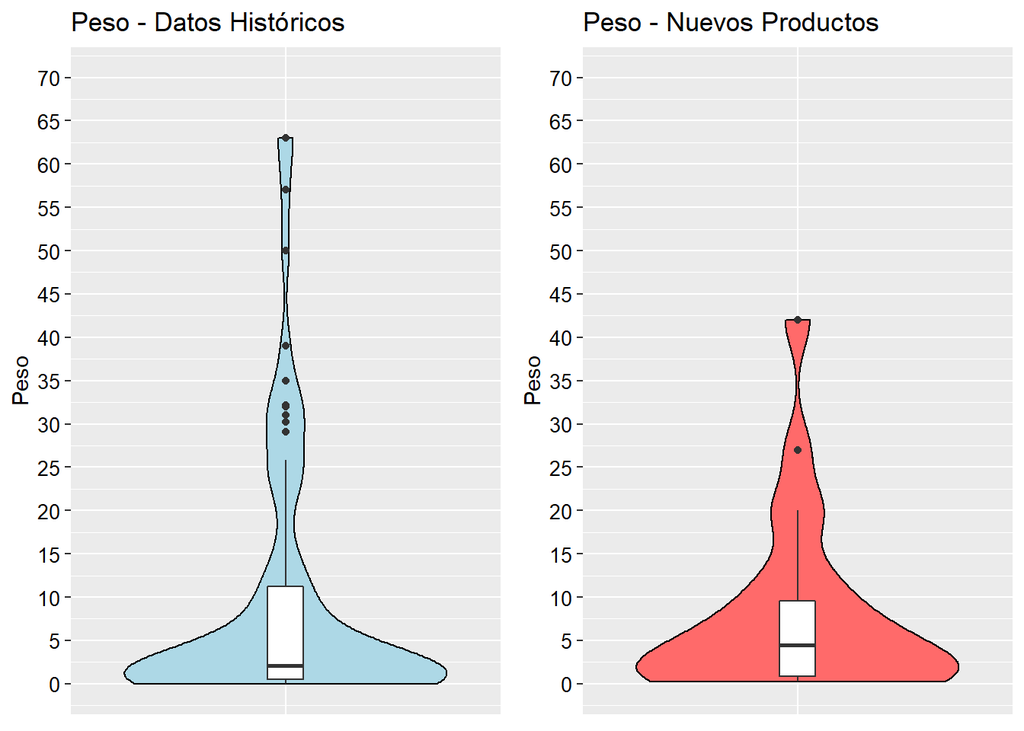

Figure 9: Distribución de la variable peso.

```r
#Violin plot Peso EPA
EPA_Peso <- ggplot(EPA,aes(x=factor(0),y=Peso))+
  geom_violin(color="black",fill='lightblue')+
  geom_boxplot(width=0.1)+
  ggtitle('Peso - Datos Históricos')+
  theme(axis.text.x=element_blank(),
        axis.ticks.x=element_blank(),
        axis.title.x=element_blank(),
        axis.text.y = element_text(color='black',size=10,angle=0))+
  scale_y_continuous(name ="Peso",limits=c(0,70),breaks=seq(0,70,5))
#Violin plot Peso NPA
NPA_Peso <- ggplot(NPA,aes(x=factor(0),y=Peso))+
  geom_violin(color="black",fill='indianred1')+
  geom_boxplot(width=0.1)+
  ggtitle('Peso - Nuevos Productos')+
  theme(axis.text.x=element_blank(),
        axis.ticks.x=element_blank(),
        axis.title.x=element_blank(),
        axis.text.y = element_text(color='black',size=10,angle=0))+
  scale_y_continuous(name ="Peso",limits=c(0,70),breaks=seq(0,70,5))
#Se muestra el gráfico
grid.arrange(EPA_Peso,NPA_Peso, ncol=2)
```

Distribuciones similares. Gran cantidad de outliers.

### 4.1.9 DIMENSIONES

Veamos la distribución de las variables referentes a las dimensiones del producto:

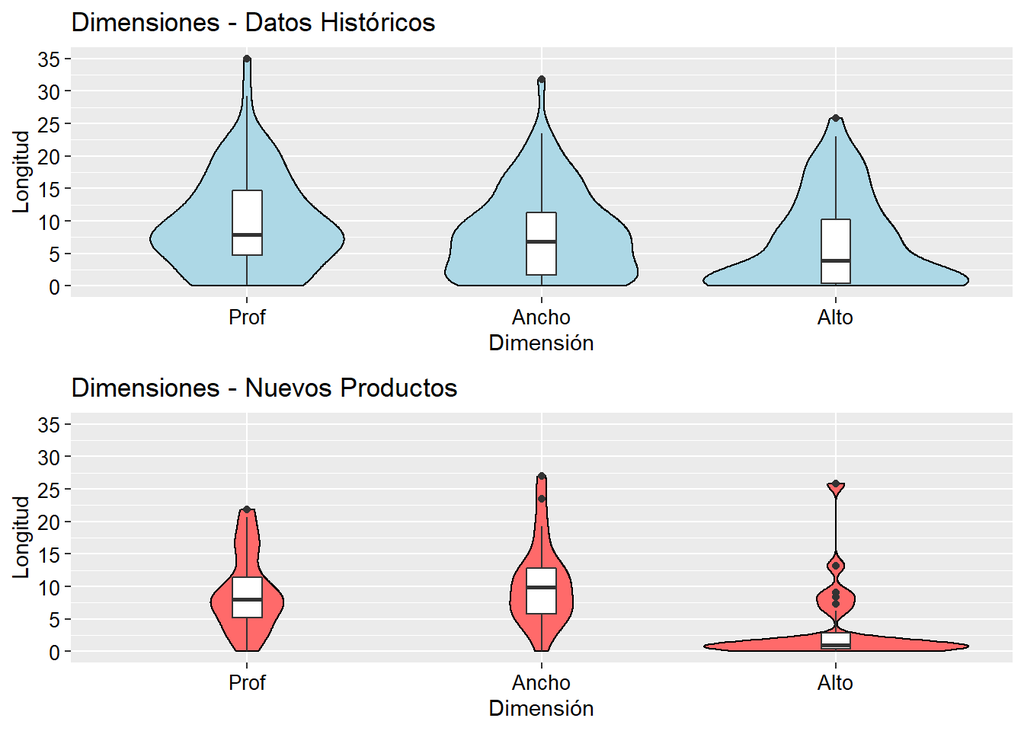

Figure 10: Distribución de las dimensiones del producto.

```r
#Violin plot Dimensiones EPA
EPA_Dimension <- gather(EPA,Dimension,N,Prof:Alto,factor_key = TRUE) %>%
              ggplot(aes(x=Dimension,y=N))+
  geom_violin(color="black",fill='lightblue')+
  geom_boxplot(width=0.1)+
  ggtitle('Dimensiones - Datos Históricos')+
  theme(axis.text.x = element_text(color='black',size=10,angle=0),
        axis.text.y = element_text(color='black',size=10,angle=0))+
  scale_y_continuous(name ="Longitud",limits=c(0,35),breaks=seq(0,35,5))+
  scale_x_discrete(name ="Dimensión")
#Violin plot Dimensiones NPA
NPA_Dimension <- gather(NPA,Dimension,N,Prof,Ancho,Alto,factor_key = TRUE) %>%
              ggplot(aes(x=Dimension,y=N))+
  geom_violin(color="black",fill='indianred1')+
  geom_boxplot(width=0.1)+
  ggtitle('Dimensiones - Nuevos Productos')+
  theme(axis.text.x = element_text(color='black',size=10,angle=0),
        axis.text.y = element_text(color='black',size=10,angle=0))+
  scale_y_continuous(name ="Longitud",limits=c(0,35),breaks=seq(0,35,5))+
  scale_x_discrete(name ="Dimensión")
#Se muestra el gráfico
grid.arrange(EPA_Dimension,NPA_Dimension, nrow=2)
```

Existen diferencias significativas en la distribución de las variables para cada uno de los conjuntso de datos.

### 4.1.10 BENEFICIO

Veamos la distribución de la variable relativa al margen de beneficio:

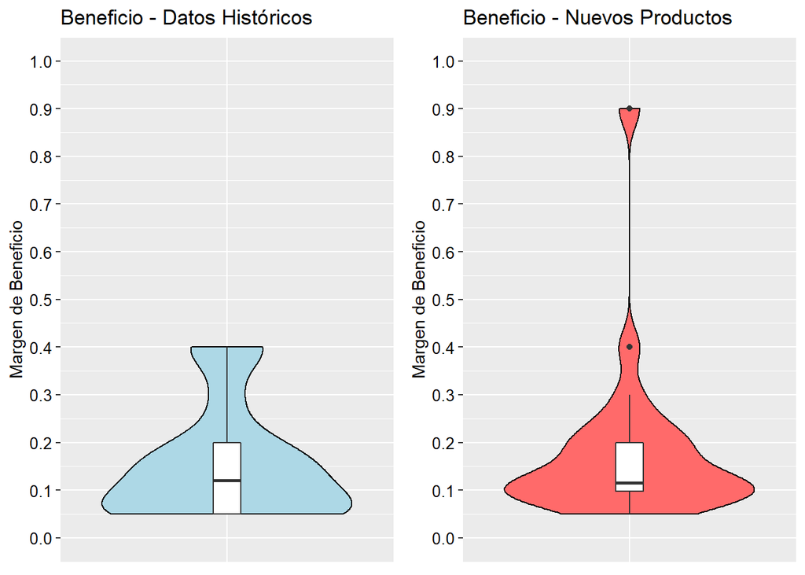

Figure 11: Distribución de la variable beneficio.

```r
#Violin plot Beneficio EPA
EPA_Beneficio <- ggplot(EPA,aes(x=factor(0),y=Beneficio))+
  geom_violin(color="black",fill='lightblue')+
  geom_boxplot(width=0.1)+
  ggtitle('Beneficio - Datos Históricos')+
  theme(axis.text.x=element_blank(),
        axis.ticks.x=element_blank(),
        axis.title.x=element_blank(),
        axis.text.y = element_text(color='black',size=10,angle=0))+
  scale_y_continuous(name ="Margen de Beneficio",limits=c(0,1),breaks=seq(0,1,0.1))
#Violin plot Beneficio NPA
NPA_Beneficio <- ggplot(NPA,aes(x=factor(0),y=Beneficio))+
  geom_violin(color="black",fill='indianred1')+
  geom_boxplot(width=0.1)+
  ggtitle('Beneficio - Nuevos Productos')+
  theme(axis.text.x=element_blank(),
        axis.ticks.x=element_blank(),
        axis.title.x=element_blank(),
        axis.text.y = element_text(color='black',size=10,angle=0))+
  scale_y_continuous(name ="Margen de Beneficio",limits=c(0,1),breaks=seq(0,1,0.1))
#Se muestra el gráfico
grid.arrange(EPA_Beneficio,NPA_Beneficio, ncol=2)
```

Distribuciones parecidas a excepción de la presencia de outliers para los nuevos productos.

### 4.1.11 VOLUMEN DE VENTAS

Veamos la distribución de la variable objetivo, volumen de ventas:

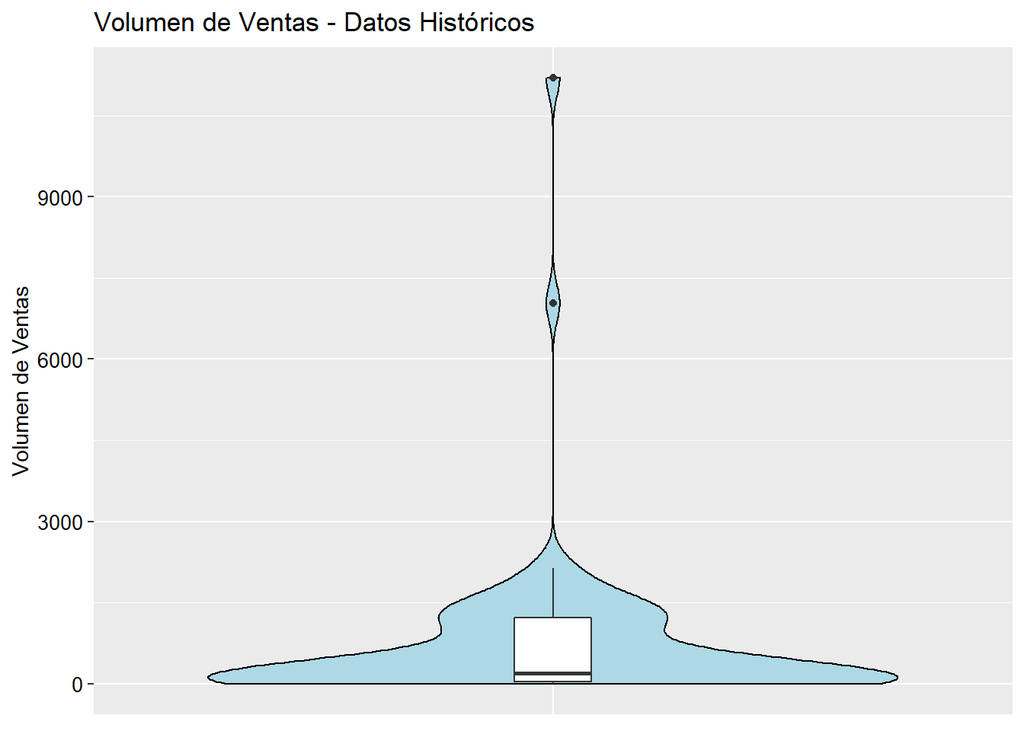

Figure 12: Distribución de la variable Volumen de Ventas.

```r
#Violin plot Beneficio EPA
EPA_Volumen <- ggplot(EPA,aes(x=factor(0),y=Volumen))+
  geom_violin(color="black",fill='lightblue')+
  geom_boxplot(width=0.1)+
  ggtitle('Volumen de Ventas - Datos Históricos')+
  theme(axis.text.x=element_blank(),
        axis.ticks.x=element_blank(),
        axis.title.x=element_blank(),
        axis.text.y = element_text(color='black',size=10,angle=0))+
  scale_y_continuous(name ="Volumen de Ventas")
EPA_Volumen
```

Tenemos dos outliers muy claros que se alejan en gran medida del resto. Además, estos outliers no pertenecen a ninguno de los tipos de producto de interés según los objetivos que se nos han marcado. Por estas razones, se decide eliminarlos del análisis:

```r
EPA <- filter(EPA, EPA$Volumen < 5000)
```

Resultando en la nueva distribución

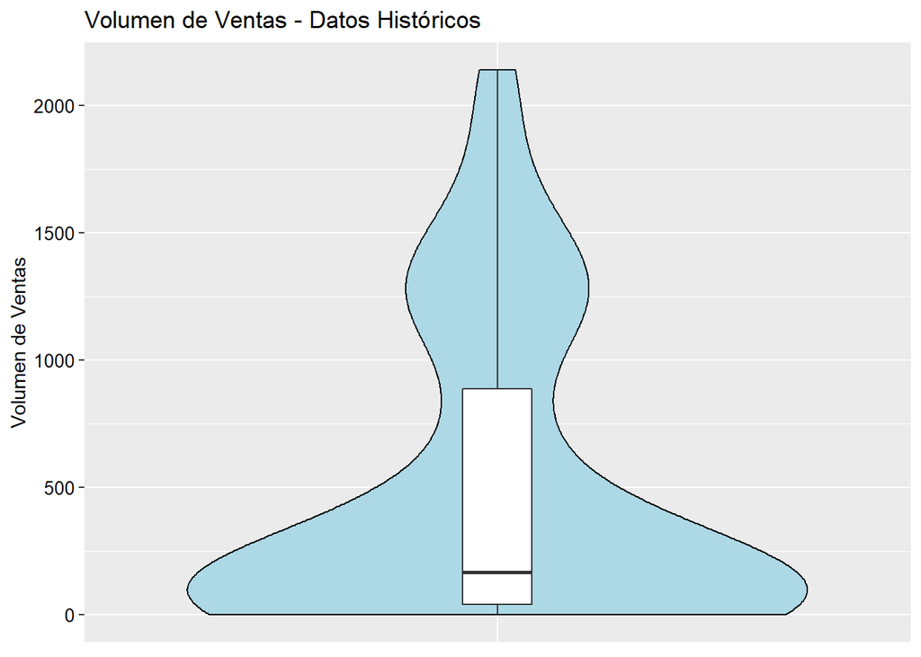

Figure 13: Distribución de la variable Volumen de Ventas. Valores atípicos eliminados.

```r
#Violin plot Beneficio EPA
EPA_Volumen2 <- ggplot(EPA,aes(x=factor(0),y=Volumen))+
  geom_violin(color="black",fill='lightblue')+
  geom_boxplot(width=0.1)+
  ggtitle('Volumen de Ventas - Datos Históricos')+
  theme(axis.text.x=element_blank(),
        axis.ticks.x=element_blank(),
        axis.title.x=element_blank(),
        axis.text.y = element_text(color='black',size=10,angle=0))+
  scale_y_continuous(name ="Volumen de Ventas")
EPA_Volumen2
```

## 4.2 ANÁLISIS BIVARIANTE

Analizamos la relación que existe entre las variables. En primer lugar realizaremos un análisis bivariante dónde se mostrará cómo se distribuye la variable objetivo en función de las demás.

### 4.2.1 VOLUMEN - TIPO

Mostramos la dependencia entre el volumen de ventas y el tipo de producto:

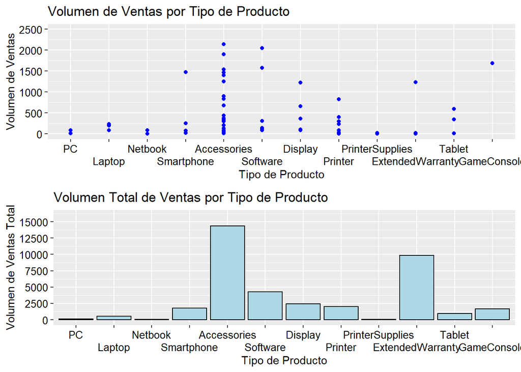

Figure 14: Distribución del Volumen de Ventas según tipo de producto.

```r
#Scatter plot Volumen - Tipo Producto
EPA_VolumenTipo <- ggplot(EPA,aes(x=Tipo,y=Volumen))+
  geom_point(color='blue')+
  ggtitle('Volumen de Ventas por Tipo de Producto')+
  theme(axis.text.y = element_text(color='black',size=10,angle=0),
        axis.text.x = element_text(color='black',size=10,angle=0))+
  scale_y_continuous(name ="Volumen de Ventas",limits=c(0,2500),breaks=seq(0,2500,500))+
  scale_x_discrete(name ="Tipo de Producto",guide=guide_axis(n.dodge=2))

#Barplot Suma Volumen - Tipo Producto
EPA_VolumenTipoSum <- aggregate(Volumen~Tipo, data=EPA, FUN=sum) %>%
              ggplot(aes(x=Tipo,y=Volumen))+
  geom_col(color="black",fill='lightblue')+
  ggtitle('Volumen Total de Ventas por Tipo de Producto')+
  theme(axis.text.y = element_text(color='black',size=10,angle=0),
        axis.text.x = element_text(color='black',size=10,angle=0))+
  scale_y_continuous(name ="Volumen de Ventas Total",limits=c(0,16000),breaks=seq(0,15000,2500))+
  scale_x_discrete(name ="Tipo de Producto",guide=guide_axis(n.dodge=2))
#Mostramos gráfico
grid.arrange(EPA_VolumenTipo,EPA_VolumenTipoSum, nrow=2)
```

Se observa que solo ciertos tipos de productos alcanzan determinados cifras de ventas. Sin embargo, todos los productos comparten cifras de ventas por lo que no es posibles diferenciarlos.

Es decir, el volumen de ventas puede darnos pistas sobre qué tipo de producto es, pero la relación no aporta información si la miramos a la inversa: tomando el tipo de producto como variable independiente, esta no aporta información sobre le volumen de ventas.

### 4.2.2 VOLUMEN - PRECIO

Mostramos la dependencia entre el volumen de ventas de un producto y el precio de este:

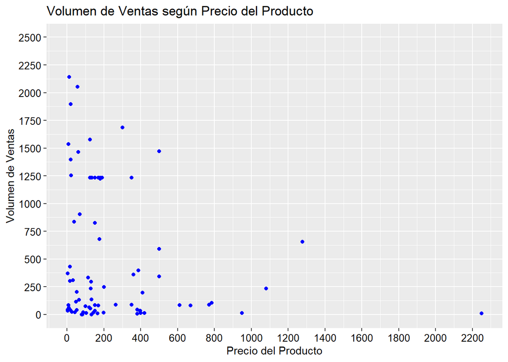

Figure 15: Distribución del Volumen de Ventas según el precio del producto.

```r
#Scatter plot Volumen - Precio
EPA_VolumenPrecio <- ggplot(EPA,aes(x=Precio,y=Volumen))+
  geom_point(color='blue')+
  ggtitle('Volumen de Ventas según Precio del Producto')+
  theme(axis.text.y = element_text(color='black',size=10,angle=0),
        axis.text.x = element_text(color='black',size=10,angle=0))+
  scale_y_continuous(name ="Volumen de Ventas",limits=c(0,2500),breaks=seq(0,2500,250))+
  scale_x_continuous(name ="Precio del Producto",limits=c(0,2250),breaks=seq(0,2250,200))
EPA_VolumenPrecio
```

Se puede observar cierta correlación ya que los mayores volúmenes de venta se concentran en rangos bajos de precio. A pesar de ello, la correlación es algo pobre.

### 4.2.3 VOLUMEN - RESEÑA

Mostramos la dependencia entre el volumen de ventas de un producto y la cantidad de reseñas para cada un de sus valores:

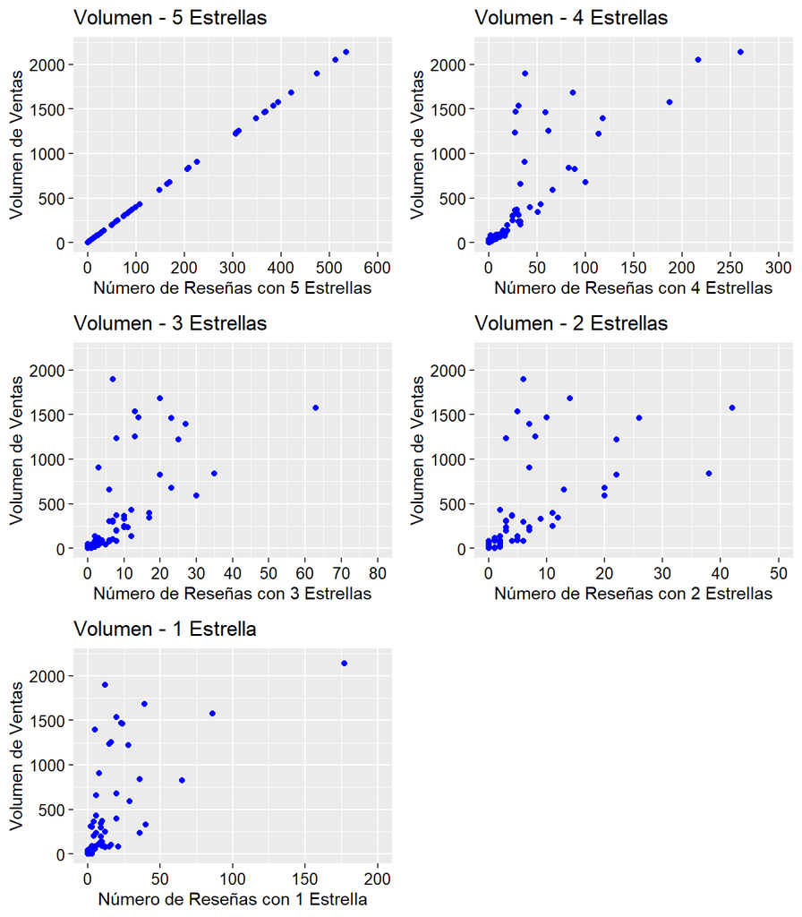

Figure 16: Distribución del Volumen de Ventas según el número de reseñas.

```r
#Scatter Plot Volumen - Reseña 5Star
EPA_VolumenStar5 <- ggplot(EPA,aes(x=Star5,y=Volumen))+
  geom_point(color='blue')+
  ggtitle('Volumen - 5 Estrellas')+
  theme(axis.text.y = element_text(color='black',size=10,angle=0),
        axis.text.x = element_text(color='black',size=10,angle=0))+
  scale_y_continuous(name ="Volumen de Ventas",limits=c(0,2200),breaks=seq(0,2500,500))+
  scale_x_continuous(name ="Número de Reseñas con 5 Estrellas",limits=c(0,600),breaks=seq(0,600,100))
#Scatter Plot Volumen - Reseña 4Star
EPA_VolumenStar4 <- ggplot(EPA,aes(x=Star4,y=Volumen))+
  geom_point(color='blue')+
  ggtitle('Volumen - 4 Estrellas')+
  theme(axis.text.y = element_text(color='black',size=10,angle=0),
        axis.text.x = element_text(color='black',size=10,angle=0))+
  scale_y_continuous(name ="Volumen de Ventas",limits=c(0,2200),breaks=seq(0,2500,500))+
  scale_x_continuous(name ="Número de Reseñas con 4 Estrellas",limits=c(0,300),breaks=seq(0,300,50))
#Scatter Plot Volumen - Reseña 3Star
EPA_VolumenStar3 <- ggplot(EPA,aes(x=Star3,y=Volumen))+
  geom_point(color='blue')+
  ggtitle('Volumen - 3 Estrellas')+
  theme(axis.text.y = element_text(color='black',size=10,angle=0),
        axis.text.x = element_text(color='black',size=10,angle=0))+
  scale_y_continuous(name ="Volumen de Ventas",limits=c(0,2200),breaks=seq(0,2500,500))+
  scale_x_continuous(name ="Número de Reseñas con 3 Estrellas",limits=c(0,80),breaks=seq(0,80,10))
#Scatter Plot Volumen - Reseña 2Star
EPA_VolumenStar2 <- ggplot(EPA,aes(x=Star2,y=Volumen))+
  geom_point(color='blue')+
  ggtitle('Volumen - 2 Estrellas')+
  theme(axis.text.y = element_text(color='black',size=10,angle=0),
        axis.text.x = element_text(color='black',size=10,angle=0))+
  scale_y_continuous(name ="Volumen de Ventas",limits=c(0,2200),breaks=seq(0,2500,500))+
  scale_x_continuous(name ="Número de Reseñas con 2 Estrellas",limits=c(0,50),breaks=seq(0,50,10))
#Scatter Plot Volumen - Reseña 1Star
EPA_VolumenStar1 <- ggplot(EPA,aes(x=Star1,y=Volumen))+
  geom_point(color='blue')+
  ggtitle('Volumen - 1 Estrella')+
  theme(axis.text.y = element_text(color='black',size=10,angle=0),
        axis.text.x = element_text(color='black',size=10,angle=0))+
  scale_y_continuous(name ="Volumen de Ventas",limits=c(0,2200),breaks=seq(0,2500,500))+
  scale_x_continuous(name ="Número de Reseñas con 1 Estrella",limits=c(0,200),breaks=seq(0,200,50))
#Mostramos gráfico
grid.arrange(EPA_VolumenStar5,EPA_VolumenStar4,EPA_VolumenStar3,
             EPA_VolumenStar2,EPA_VolumenStar1,nrow=3, ncol=2)
```

Para reseñas de 5 estrellas tenemos una correlación perfecta. Las reseñas de 4 estrellas siguen mostrando una tendencia clara. A medida que el valor de la reseña baja, la correlación es cada vez más pobre. La razón es que para malas reseñas, tenemos dos tendencias contrarias:

- A mayor volumen de ventas, mayor número de reseñas tendremos, entre ellas las negativas.
- A mayor número de reseñas negativas, más clientes decidirán no comprar el producto.

Por esta razón, se considera representar esta variable dándole otro enfoque. Podemos representar el volumen de ventas en función de la valoración media y el número de reseñas. Veamos estos resultados.

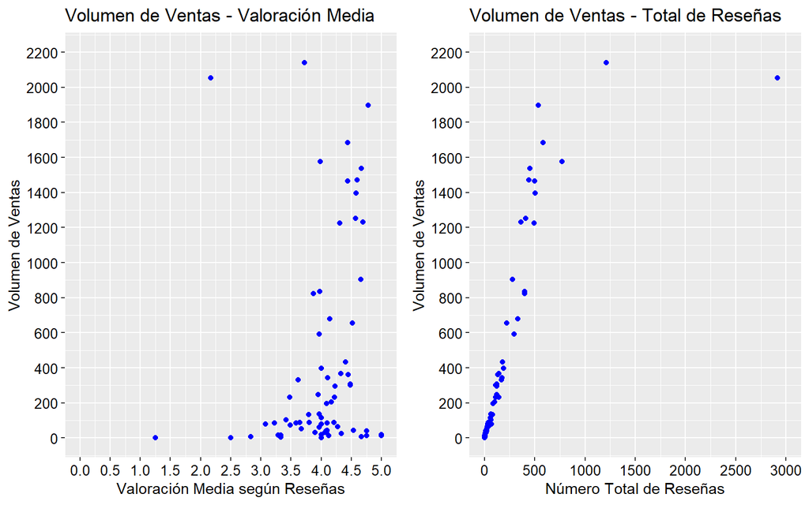

Figure 17: Distribución del Volumen de Ventas según la valoración media de las reseñas.

```r
#Scatter Plot Volumen - Reseña Media
EPA_VolumenStarM <- ggplot(EPA,aes(x=StarM,y=Volumen))+
  geom_point(color='blue')+
  ggtitle('Volumen de Ventas - Valoración Media')+
  theme(axis.text.y = element_text(color='black',size=10,angle=0),
        axis.text.x = element_text(color='black',size=10,angle=0))+
  scale_y_continuous(name ="Volumen de Ventas",limits=c(0,2200),breaks=seq(0,2200,200))+
  scale_x_continuous(name ="Valoración Media según Reseñas",limits=c(0,5),breaks=seq(0,5,0.5))
#Scatter Plot Volumen - Reseña Totales
EPA_VolumenNRes <- ggplot(EPA,aes(x=NRes,y=Volumen))+
  geom_point(color='blue')+
  ggtitle('Volumen de Ventas - Total de Reseñas')+
  theme(axis.text.y = element_text(color='black',size=10,angle=0),
        axis.text.x = element_text(color='black',size=10,angle=0))+
  scale_y_continuous(name ="Volumen de Ventas",limits=c(0,2200),breaks=seq(0,2200,200))+
  scale_x_continuous(name ="Número Total de Reseñas",limits=c(0,3000),breaks=seq(0,3000,500))
ggarrange(EPA_VolumenStarM,EPA_VolumenNRes,nrow=1)
```

El número total de reseñas muestra una correlación muy buena a excepción de dos puntos que se alejan de la tendencia del resto. Estos puntos coinciden con los productos con mayor númeor de reseñas.

La valoración media no deja en evidencia una tendencia tan clara. Para un determinado valor de la reseña media ponderada existen muchos puntos en un rango de ventas muy amplio, por lo que no parece que vaya a aportar tanta información.

### 4.2.4 VOLUMEN - RESEÑA DEL SERVICIO

Mostramos la dependencia entre el volumen de ventas de un producto y la cantidad de reseñas referentes al servicio:

[figure not shown]

```r
#Scatter Plot Volumen - Reseñas Positivas Servicio
EPA_VolumenPositiva <- ggplot(EPA,aes(x=SerPos,y=Volumen))+
  geom_point(color='blue')+
  ggtitle('Volumen de Ventas según Reseñas Positivas')+
  theme(axis.text.y = element_text(color='black',size=10,angle=0),
        axis.text.x = element_text(color='black',size=10,angle=0))+
  scale_y_continuous(name ="Volumen de Ventas",limits=c(0,2200),breaks=seq(0,2200,200))+
  scale_x_continuous(name ="Número de Reseñas Positivas",limits=c(0,350),breaks=seq(0,350,50))
#Scatter Plot Volumen - Reseñas Negativas Servicio
EPA_VolumenNegativa <- ggplot(EPA,aes(x=Star4,y=Volumen))+
  geom_point(color='blue')+
  ggtitle('Volumen de Ventas según Reseñas Negativas')+
  theme(axis.text.y = element_text(color='black',size=10,angle=0),
        axis.text.x = element_text(color='black',size=10,angle=0))+
  scale_y_continuous(name ="Volumen de Ventas",limits=c(0,2200),breaks=seq(0,2200,200))+
  scale_x_continuous(name ="Número de Reseñas Negativas",limits=c(0,120),breaks=seq(0,120,10))
#Mostramos gráfico
grid.arrange(EPA_VolumenPositiva,EPA_VolumenNegativa,ncol=2)
```

Las reseñas positivas del servicio siguen una tendencia parecida al total de reseñas. Describen una tendencia clara a excepción de dos puntos muy diferenciados.

Creamos una nueva variable con la fracción de reseñas positivas sobre el total y vemos la información que nos aporta para predecir la variable objetivo.

```r
#Se calcula la reseña media
EPA$SerFra <- EPA %>% with(SerPos/(SerPos+SerNeg))
#Se substituyen los 0/0 por 0
EPA$SerFra[is.na(EPA$SerFra)] <- 0
```

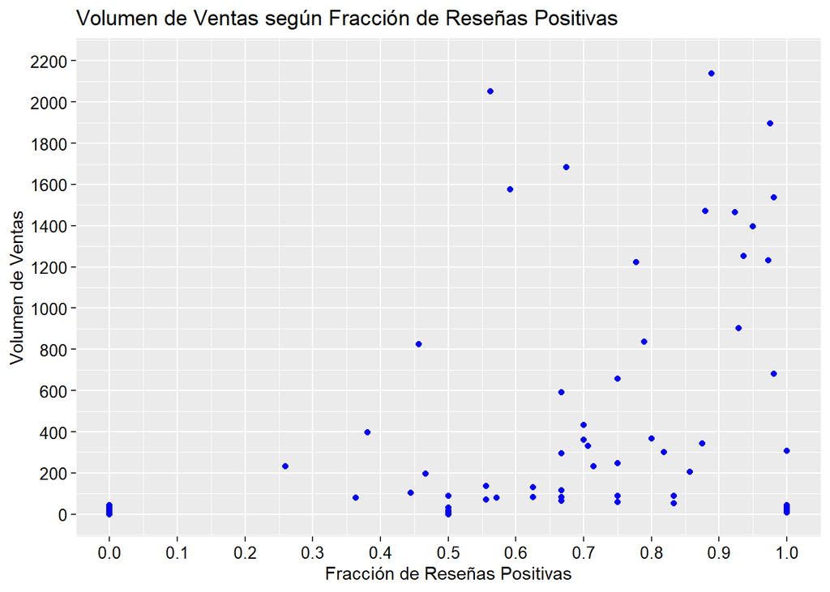

Figure 19: Distribución del Volumen de Ventas según la fracción de reseñas positivas.

```r
#Scatter Plot Volumen - Fracción Reseñas Positivas Servicio
EPA_VolumenFraccion <- ggplot(EPA,aes(x=SerFra,y=Volumen,))+
  geom_point(color='blue')+
  ggtitle('Volumen de Ventas según Fracción de Reseñas Positivas')+
  theme(axis.text.y = element_text(color='black',size=10,angle=0),
        axis.text.x = element_text(color='black',size=10,angle=0))+
  scale_y_continuous(name ="Volumen de Ventas",limits=c(0,2200),breaks=seq(0,2200,200))+
  scale_x_continuous(name ="Fracción de Reseñas Positivas",limits=c(0,1),breaks=seq(0,1,0.1))
#Mostramos gráfico
EPA_VolumenFraccion
```

Hay cierta correlación pero no es tan clara como que nos porporciona el total de reseñas positivas.

### 4.2.5 VOLUMEN - GRADO DE RECOMENDACIÓN

Mostramos la dependencia entre el volumen de ventas de un producto y el grado de recomendación por parte del usuario:

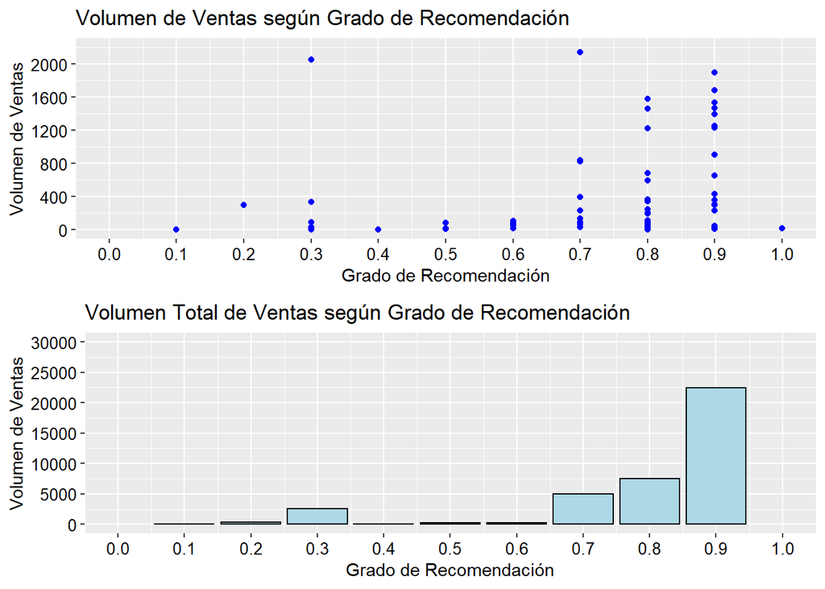

Figure 20: Distribución del Volumen de Ventas según el grado de recomendación.

```r
#Scatter Plot Volumen - Grado de Recomendación
EPA_VolumenRecomendacion <- ggplot(EPA,aes(x=Reco,y=Volumen))+
  geom_point(color='blue')+
  ggtitle('Volumen de Ventas según Grado de Recomendación')+
  theme(axis.text.y = element_text(color='black',size=10,angle=0),
        axis.text.x = element_text(color='black',size=10,angle=0))+
  scale_y_continuous(name ="Volumen de Ventas",limits=c(0,2200),breaks=seq(0,2400,400))+
  scale_x_continuous(name ="Grado de Recomendación",limits=c(0,1),breaks=seq(0,1,0.1))
#Barplot Suma Volumen - Grado de Recomendación
EPA_VolumenRecomendacionSum <- aggregate(Volumen~Reco, data=EPA, FUN=sum) %>%
              ggplot(aes(x=Reco,y=Volumen))+
  geom_col(color="black",fill='lightblue')+
  ggtitle('Volumen Total de Ventas según Grado de Recomendación')+
  theme(axis.text.y = element_text(color='black',size=10,angle=0),
        axis.text.x = element_text(color='black',size=10,angle=0))+
  scale_y_continuous(name ="Volumen de Ventas",limits=c(0,30000),breaks=seq(0,30000,5000))+
  scale_x_continuous(name ="Grado de Recomendación",limits=c(0,1),breaks=seq(0,1,0.1))
#Mostramos gráfico
ggarrange(EPA_VolumenRecomendacion,EPA_VolumenRecomendacionSum, nrow=2)
```

Todos los valores del grado de recomendación comparten volúmenes de venta por lo que no es posible distinguir en base a esta variable de forma inequívoca.

### 4.2.6 VOLUMEN - RANKING

Mostramos la dependencia entre el volumen de ventas de un producto y la posición que ocupa el producto en el ranking de ventas:

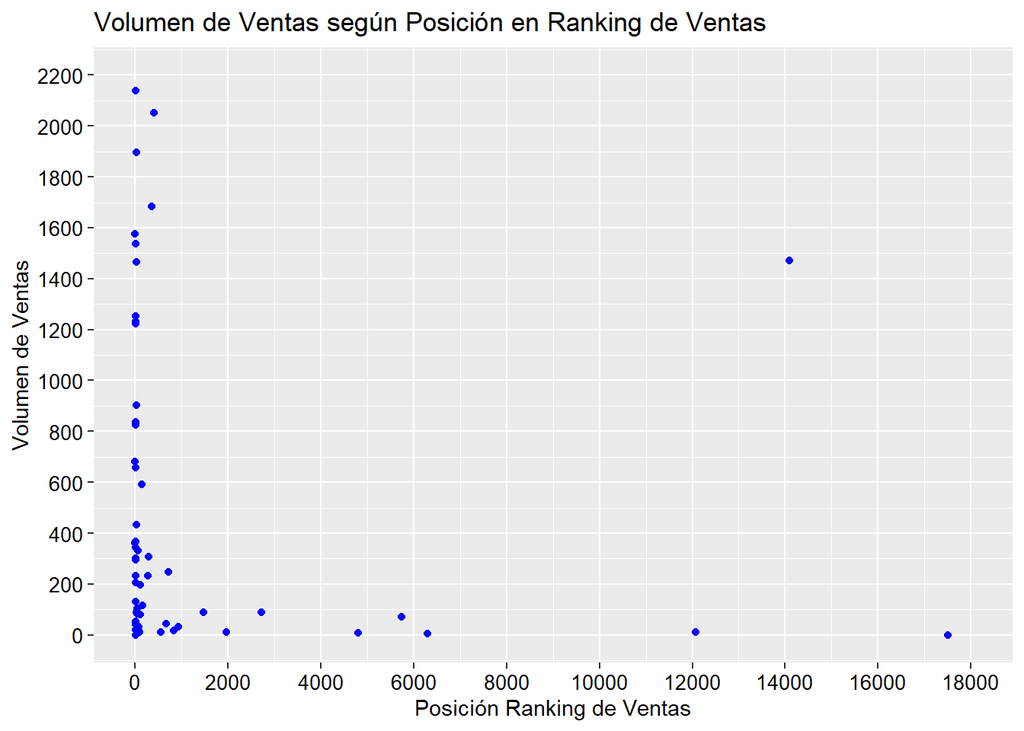

Figure 21: Distribución del Volumen de Ventas según su posición en el ranking de ventas.

```r
#Scatter Plot Volumen - Ranking de ventas
EPA_VolumenRanking <- ggplot(EPA,aes(x=Ranking,y=Volumen))+
  geom_point(color='blue')+
  ggtitle('Volumen de Ventas según Posición en Ranking de Ventas')+
  theme(axis.text.y = element_text(color='black',size=10,angle=0),
        axis.text.x = element_text(color='black',size=10,angle=0))+
  scale_y_continuous(name ="Volumen de Ventas",limits=c(0,2200),breaks=seq(0,2200,200))+
  scale_x_continuous(name ="Posición Ranking de Ventas",limits=c(0,18000),breaks=seq(0,18000,2000))
#Mostramos gráfico
EPA_VolumenRanking
```

Recordemos que esta variable contenía 15/80 (casi 20%) missing values. Además, no parece haber una buena correlación entre las variables. En vista a la mala correlación con la variable objetivo, se decide no tratar los missing values y descartar la variable como variable predictora.

```r
#Se descarta variable ranking
EPA$Ranking <- NULL
```

### 4.2.7 VOLUMEN - PESO

Mostramos la dependencia entre el volumen de ventas de un producto y su peso:

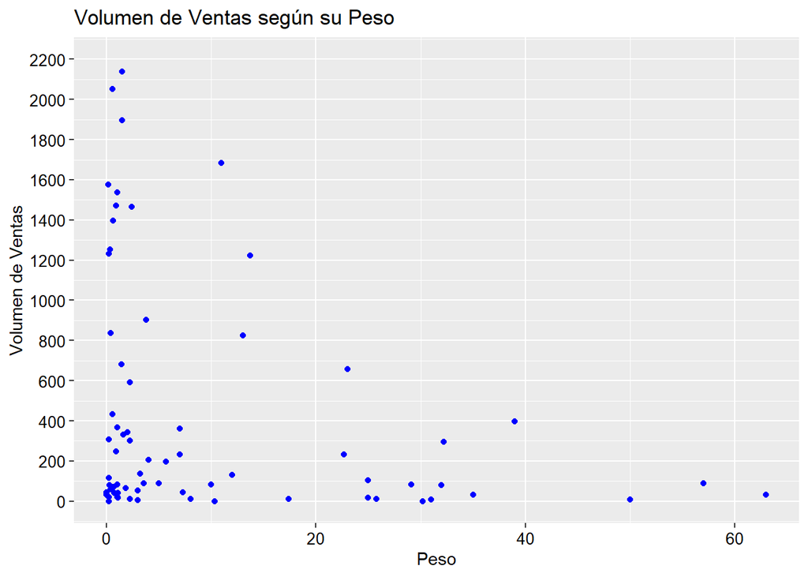

Figure 22: Distribución del Volumen de Ventas según su peso.

```r
#Scatter Plot Volumen - Peso
EPA_VolumenPeso <- ggplot(EPA,aes(x=Peso,y=Volumen))+
  geom_point(color='blue')+
  ggtitle('Volumen de Ventas según su Peso')+
  theme(axis.text.y = element_text(color='black',size=10,angle=0),
        axis.text.x = element_text(color='black',size=10,angle=0))+
  scale_y_continuous(name ="Volumen de Ventas",limits=c(0,2200),breaks=seq(0,2200,200))+
  scale_x_continuous(name ="Peso")
#Mostramos gráfico
EPA_VolumenPeso
```

Está claro que el peso es siempre un inconveniente y, tal y como muestra el gráfico, a mayor peso el volumen de ventas disminuye. Sin embargo, esta correlación es algo pobre por lo que deben haber otros criterios que tengan más influencia en las ventas del producto.

### 4.2.8 VOLUMEN - DIMENSIONES

Mostramos la dependencia entre el volumen de ventas de un producto y sus dimensiones:

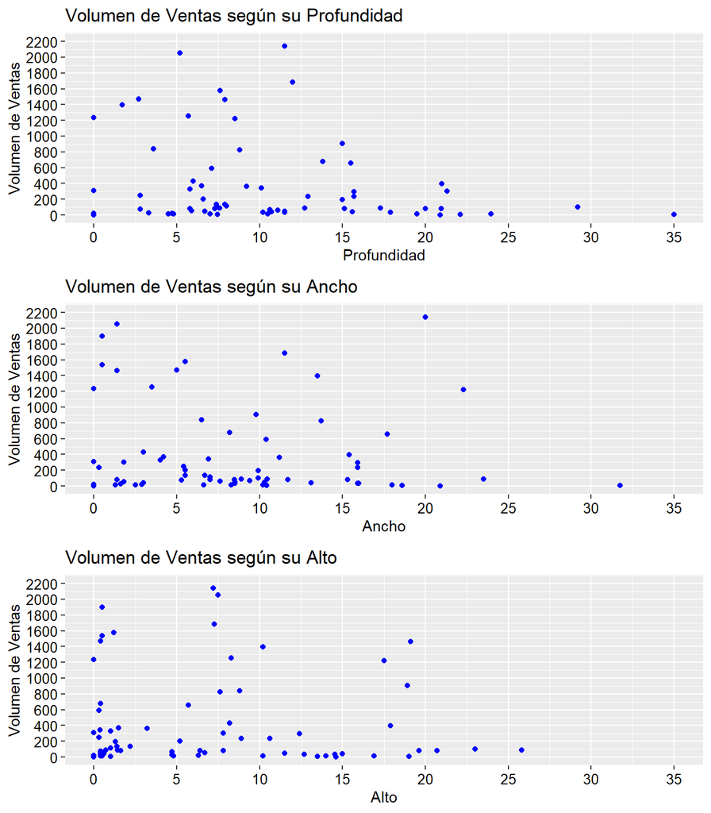

Figure 23: Distribución del Volumen de Ventas según sus dimensiones.

```r
#Scatter Plot Volumen - Profundidad
EPA_VolumenProfundidad <- ggplot(EPA,aes(x=Prof,y=Volumen))+
  geom_point(color='blue')+
  ggtitle('Volumen de Ventas según su Profundidad')+
  theme(axis.text.y = element_text(color='black',size=10,angle=0),
        axis.text.x = element_text(color='black',size=10,angle=0))+
  scale_y_continuous(name ="Volumen de Ventas",limits=c(0,2200),breaks=seq(0,2200,200))+
  scale_x_continuous(name ="Profundidad",limits=c(0,35),breaks=seq(0,35,5))
#Scatter Plot Volumen - Ancho
EPA_VolumenAncho <- ggplot(EPA,aes(x=Ancho,y=Volumen))+
  geom_point(color='blue')+
  ggtitle('Volumen de Ventas según su Ancho')+
  theme(axis.text.y = element_text(color='black',size=10,angle=0),
        axis.text.x = element_text(color='black',size=10,angle=0))+
  scale_y_continuous(name ="Volumen de Ventas",limits=c(0,2200),breaks=seq(0,2200,200))+
  scale_x_continuous(name ="Ancho",limits=c(0,35),breaks=seq(0,35,5))
#Scatter Plot Volumen - Alto
EPA_VolumenAlto <- ggplot(EPA,aes(x=Alto,y=Volumen))+
  geom_point(color='blue')+
  ggtitle('Volumen de Ventas según su Alto')+
  theme(axis.text.y = element_text(color='black',size=10,angle=0),
        axis.text.x = element_text(color='black',size=10,angle=0))+
  scale_y_continuous(name ="Volumen de Ventas",limits=c(0,2200),breaks=seq(0,2200,200))+
  scale_x_continuous(name ="Alto",limits=c(0,35),breaks=seq(0,35,5))
#Mostramos gráfico
grid.arrange(EPA_VolumenProfundidad,EPA_VolumenAncho,EPA_VolumenAlto,nrow=3)
```

No se observa correlación alguna y podríamos decir que el volumen de ventas es independiente de las dimensiones del producto.

### 4.2.9 VOLUMEN - MARGEN DE BENEFICIO

Mostramos la dependencia entre el volumen de ventas de un producto y su margen de beneficio:

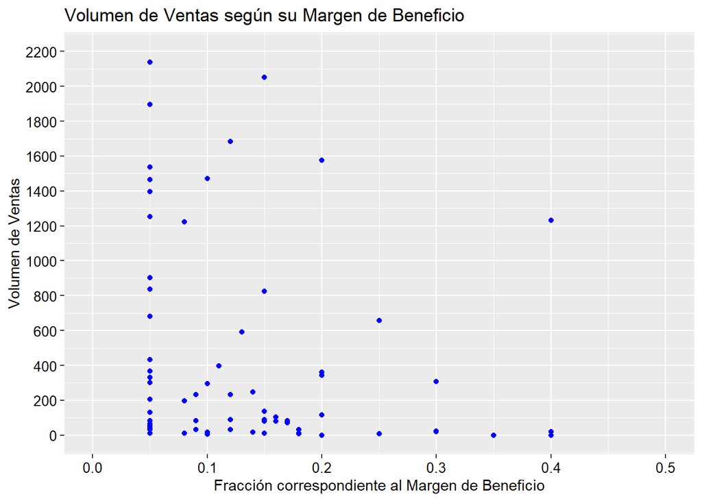

Figure 24: Distribución del Volumen de Ventas según el margen de beneficio asociado.

```r
#Scatter Plot Volumen - Beneficio
EPA_VolumenBeneficio <- ggplot(EPA,aes(x=Beneficio,y=Volumen))+
  geom_point(color='blue')+
  ggtitle('Volumen de Ventas según su Margen de Beneficio')+
  theme(axis.text.y = element_text(color='black',size=10,angle=0),
        axis.text.x = element_text(color='black',size=10,angle=0))+
  scale_y_continuous(name ="Volumen de Ventas",limits=c(0,2200),breaks=seq(0,2200,200))+
  scale_x_continuous(name ="Fracción correspondiente al Margen de Beneficio",limits=c(0,0.5),breaks=seq(0,0.5,0.1))
#Mostramos gráfico
EPA_VolumenBeneficio
```

La correlación es muy pobre aunque se observa que los productos con mejores números en ventas se concentran alrededor de márgenes bajos de beneficio.

## 4.3 ANÁLISIS MULTIVARIANTE

El objetivo es mostrar gráficos algo más complejos donde se visualicen tantas variables como sea posible.

### 4.3.1 VOLUMEN - RESEÑA - TIPO PRODUCTO

Debido a que una de las tareas a realizar consiste en predecir las ventas de ciertos tipos de productos, se va a mostrar el volumen de ventas en función del tipo de producto junto al número de reseña. Esta última se considera por ser la variable que más información nos aporta.

Así pues, mostramos la dependencia entre el volumen de ventas de un producto y la cantidad de reseñas para cada tipo de producto:

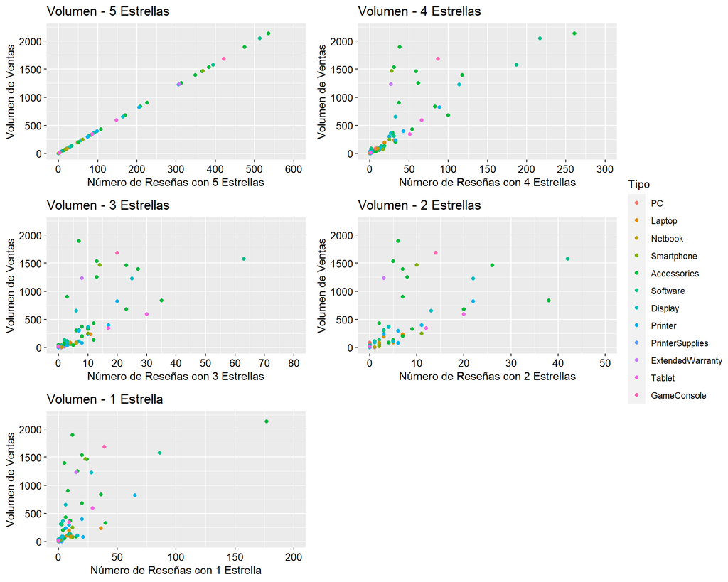

Figure 25: Distribución del Volumen de Ventas según número de reseñas y tipo de producto.

```r
#Scatter Plot Volumen - Reseña 5Star - Tipo
EPA_VolumenStar5Tipo <- ggplot(EPA,aes(x=Star5,y=Volumen,color=Tipo))+geom_point()+
  ggtitle('Volumen - 5 Estrellas')+
  theme(axis.text.y = element_text(color='black',size=10,angle=0),
        axis.text.x = element_text(color='black',size=10,angle=0))+
  scale_y_continuous(name ="Volumen de Ventas",limits=c(0,2200),breaks=seq(0,2500,500))+
  scale_x_continuous(name ="Número de Reseñas con 5 Estrellas",limits=c(0,600),breaks=seq(0,600,100))
#Scatter Plot Volumen - Reseña 4Star - Tipo
EPA_VolumenStar4Tipo <- ggplot(EPA,aes(x=Star4,y=Volumen,color=Tipo))+geom_point()+
  ggtitle('Volumen - 4 Estrellas')+
  theme(axis.text.y = element_text(color='black',size=10,angle=0),
        axis.text.x = element_text(color='black',size=10,angle=0))+
  scale_y_continuous(name ="Volumen de Ventas",limits=c(0,2200),breaks=seq(0,2500,500))+
  scale_x_continuous(name ="Número de Reseñas con 4 Estrellas",limits=c(0,300),breaks=seq(0,300,50))
#Scatter Plot Volumen - Reseña 3Star - Tipo
EPA_VolumenStar3Tipo <- ggplot(EPA,aes(x=Star3,y=Volumen,color=Tipo))+geom_point()+
  ggtitle('Volumen - 3 Estrellas')+
  theme(axis.text.y = element_text(color='black',size=10,angle=0),
        axis.text.x = element_text(color='black',size=10,angle=0))+
  scale_y_continuous(name ="Volumen de Ventas",limits=c(0,2200),breaks=seq(0,2500,500))+
  scale_x_continuous(name ="Número de Reseñas con 3 Estrellas",limits=c(0,80),breaks=seq(0,80,10))
#Scatter Plot Volumen - Reseña 2Star - Tipo
EPA_VolumenStar2Tipo <- ggplot(EPA,aes(x=Star2,y=Volumen,color=Tipo))+geom_point()+
  ggtitle('Volumen - 2 Estrellas')+
  theme(axis.text.y = element_text(color='black',size=10,angle=0),
        axis.text.x = element_text(color='black',size=10,angle=0))+
  scale_y_continuous(name ="Volumen de Ventas",limits=c(0,2200),breaks=seq(0,2500,500))+
  scale_x_continuous(name ="Número de Reseñas con 2 Estrellas",limits=c(0,50),breaks=seq(0,50,10))
#Scatter Plot Volumen - Reseña 1Star - Tipo
EPA_VolumenStar1Tipo <- ggplot(EPA,aes(x=Star1,y=Volumen,color=Tipo))+geom_point()+
  ggtitle('Volumen - 1 Estrella')+
  theme(axis.text.y = element_text(color='black',size=10,angle=0),
        axis.text.x = element_text(color='black',size=10,angle=0))+
  scale_y_continuous(name ="Volumen de Ventas",limits=c(0,2200),breaks=seq(0,2500,500))+
  scale_x_continuous(name ="Número de Reseñas con 1 Estrella",limits=c(0,200),breaks=seq(0,200,50))
#Mostramos gráfico
ggarrange(EPA_VolumenStar5Tipo,EPA_VolumenStar4Tipo,EPA_VolumenStar3Tipo,
             EPA_VolumenStar2Tipo,EPA_VolumenStar1Tipo,nrow=3, ncol=2, common.legend = TRUE, legend="right")
```

El tipo de producto no juega ningún papel y no permite distinguir el volumen de venta. Las reseñas de usuarios tienen la misma influencia sobre todos los productos sin importar a qué clase pertenecen.

Veamos si se diferencia algún patrón para la valoración media.

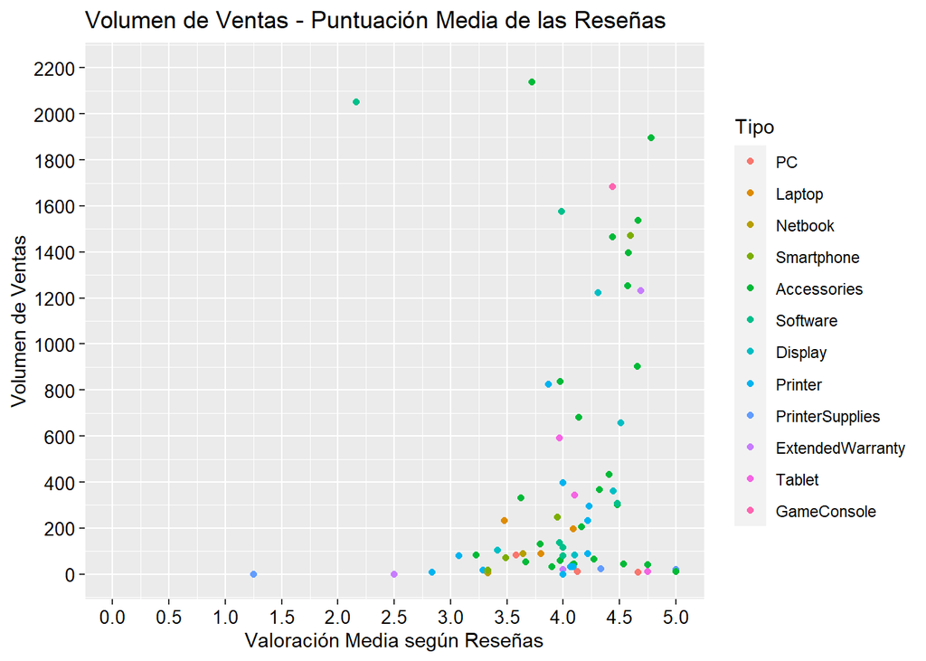

Figure 26: Distribución del Volumen de Ventas según la valoración media de las reseñas.

```r
#Scatter Plot Volumen - Reseña Media
EPA_VolumenStarMTipo <- ggplot(EPA,aes(x=StarM,y=Volumen,color=Tipo))+geom_point()+
  ggtitle('Volumen de Ventas - Puntuación Media de las Reseñas')+
  theme(axis.text.y = element_text(color='black',size=10,angle=0),
        axis.text.x = element_text(color='black',size=10,angle=0))+
  scale_y_continuous(name ="Volumen de Ventas",limits=c(0,2200),breaks=seq(0,2200,200))+
  scale_x_continuous(name ="Valoración Media según Reseñas",limits=c(0,5),breaks=seq(0,5,0.5))
EPA_VolumenStarMTipo
```

De nuevo no existe patrón según el tipo de producto.

Se han realizado otras pruebas combinando el tipo de producto con el resto de variables sin obtener resultados útiles que nos permitan diferenciar patrones. Dada la extensión de estos resultados y su poca relevancia para el análisis, se decide omitirlos.

### 4.3.2 VOLUMEN - VALOR MEDIO RESEÑAS - TOTAL RESEÑAS

Con el objetivo de dar respuesta a la segunda de las preguntas planteadas, se decide crear gráficos que relacionen el voluemn de ventas, la valoración media de las reseñas y la cantidad total de estas.

Este ejercicio se realiza tanto para las reseñas del usuario sobre el producto, como para las reseñas del servicio prestado. Veamos el primer caso:

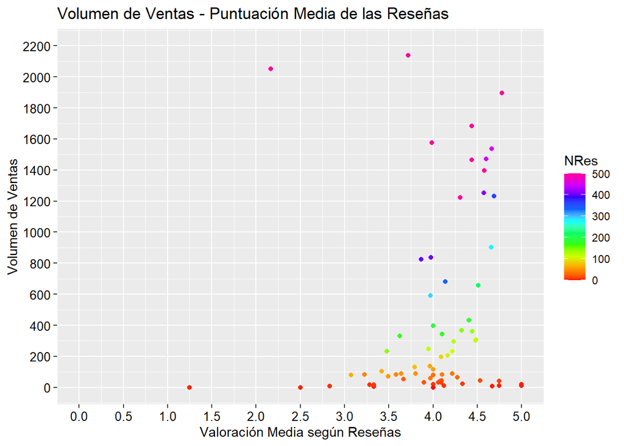

Figure 27: Distribución del Volumen de Ventas según la valoración media y el Nº Reseñas.

```r
#Se calcula el número de reseñas totales
EPA$NRes <- EPA %>% with(Star5+Star4+Star3+Star2+Star1)
#Scatter Plot Volumen - Reseña Media
EPA_VolumenNStarM <- ggplot(EPA,aes(x=StarM,y=Volumen,color=NRes))+
  geom_point()+scale_colour_gradientn(colours = rainbow(10),limits=c(0,500),na.value ="#FF0099")+
  ggtitle('Volumen de Ventas - Puntuación Media de las Reseñas')+
  theme(axis.text.y = element_text(color='black',size=10,angle=0),
        axis.text.x = element_text(color='black',size=10,angle=0))+
  scale_y_continuous(name ="Volumen de Ventas",limits=c(0,2200),breaks=seq(0,2200,200))+
  scale_x_continuous(name ="Valoración Media según Reseñas",limits=c(0,5),breaks=seq(0,5,0.5))
EPA_VolumenNStarM
```

El gráfico muestra una tendencia muy clara. El valor medio de las reseñas tiene cierta influencia en el volumen de ventas. Sin embargo, existe una condición para que se dé esta dependencia: el número de reseñas. Una buena valoración media no es relevante si no viene acompañada por una cantidad significativa de reseñas.

Hagamos el mismo ejercicio para las reseñas del servicio.

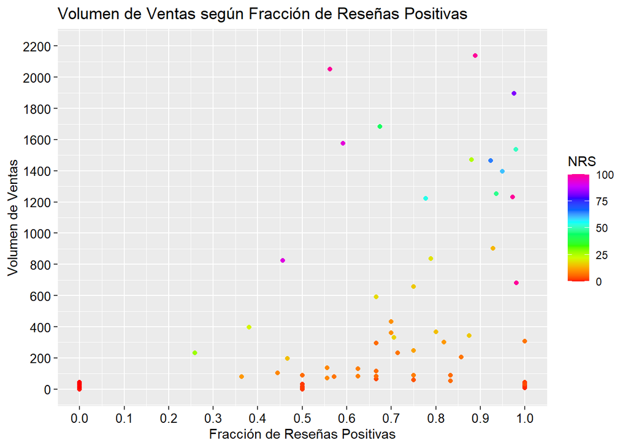

Figure 28: Distribución del Volumen de Ventas según la cantidad de reseñas del servicio y la fracción positiva de estas.

```r
#Número de reseñas de servicio
EPA$NRS <- EPA %>% with(SerPos+SerNeg)
#Scatter Plot Volumen - Fracción Reseñas Positivas Servicio
EPA_VolumenNFraccion <- ggplot(EPA,aes(x=SerFra,y=Volumen,color=NRS))+
  geom_point()+scale_colour_gradientn(colours = rainbow(10),limits=c(0,100),na.value ="#FF0099")+
  ggtitle('Volumen de Ventas según Fracción de Reseñas Positivas')+
  theme(axis.text.y = element_text(color='black',size=10,angle=0),
        axis.text.x = element_text(color='black',size=10,angle=0))+
  scale_y_continuous(name ="Volumen de Ventas",limits=c(0,2200),breaks=seq(0,2200,200))+
  scale_x_continuous(name ="Fracción de Reseñas Positivas",limits=c(0,1),breaks=seq(0,1,0.1))
#Mostramos gráfico
EPA_VolumenNFraccion
```

Vemos que el ejemplo anterior sigue aplicando para las reseñas del servicio (los puntos en rojo siguen dominando para bajos volúmenes de venta). Sin embargo, a diferencia del caso anterior, los productos con una cantidad de reseñas moderada o alta no siguen un patrón tan claro.

### 4.3.3 MATRIZ DE COVARIANCIA

Se muestra la matriz de covariancia a modo de resumen para ver las dependencias entre todas las variables.

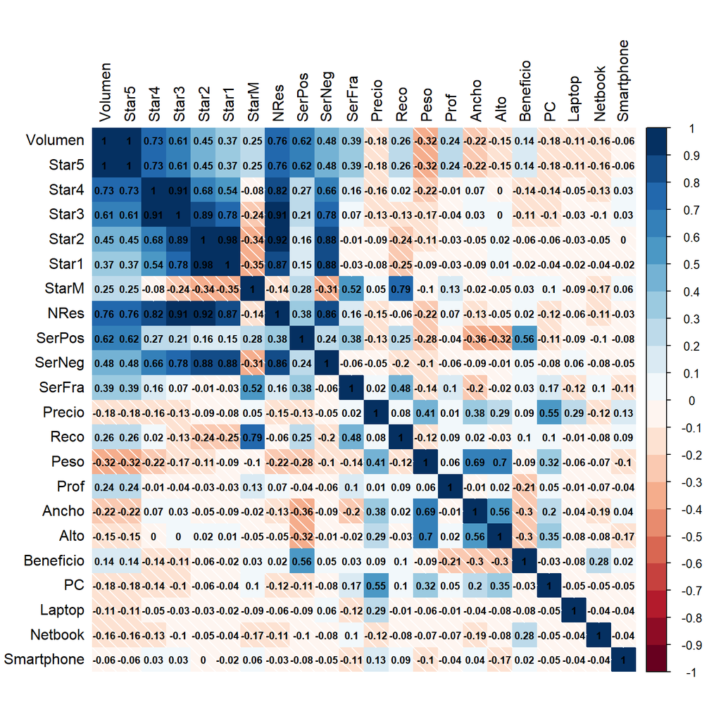

Figure 29: Matriz de Correlación.

```r
Variables <- c('Volumen','Star5','Star4','Star3','Star2','Star1','StarM','NRes',
                  'SerPos','SerNeg','SerFra','Precio','Reco','Peso','Prof','Ancho','Alto',
                  'Beneficio','PC','Laptop','Netbook','Smartphone')
#Se muestra matriz de correlación
EPA[Variables] %>% cor() %>% corrplot(method='shade', number.digits = 2, number.cex = 0.7,tl.col='black',
                                     tl.cex=1,col = COL2('RdBu', 20), addCoef.col = 'black')
```

Los resultados de la matriz son esenciales para detectar qué variables son claves en la predicción, así como identificar qué variables predictoras son colineales entre ellas. En los siguientes apartados abordaremos este punto.

# 5 MODELADO

El objetivo en esta sección es crear un modelo que nos permita predecir con precisión el volumen de ventas para los nuevos productos.

## 5.1 PLANTEAMIENTO

Se ajustarán varios modelos a los datos existentes. Tras obtener todos estos modelos, se escogerá el que nos proporcione mejores resultados. No solo consideraremos las métricas del error, el tiempo de ejecución será un factor a tener en cuenta.

Se escogerá algoritmo entre los siguientes:

- Random Forest
- Support Vector Machine
  - Lineal
  - Kernel Radial
- Gradient Boosting
- K-Nearest Neighbor

Antes de entrar en el ajuste de modelos, debemos realizar dos pasos más: la partición de datos y la selección de variables independientes.

## 5.2 DEFINICIÓN DE LA PARTICIÓN DE DATOS

Realizamos la partición en los conjuntos de datos de entramiento y test. El tamaño del conjunto de entrenamiento representará el 70% del total de datos.

```r
#Se fija una semilla para conseguir reproducibilidad
set.seed(100)
# define una partición 75%/25% train/test del conjunto de datos
SplitPartition <- createDataPartition(EPA$Volumen, p = 0.7, list = FALSE)
#Obtenemos una primera partición. El conjunto Test se reserva para la evaluación del modelo definitivo
EPA_Training <- EPA[SplitPartition,]
EPA_Test <- EPA[-SplitPartition,]
```

## 5.3 SELECCIÓN DE LAS VARIABLES INDEPENDIENTES

En este apartado seleccionaremos las variables independientes. Dados los resultados del análisis exploratorio y la matriz de correlación, las variables que tienen un mayor peso con diferencia son las relacionadas con las reseñas, tanto del producto como del servicio.

Limitaremos la selección de variables a las más relevantes. La razón recae en el coste computacional: incorporar variables irrelevantes tiene un gran inconveniente y es que multiplicaría el tiempo de cálculo, el cual se tratará también como otro criterio de selección.

Revisando los resulados de la matriz de correlación en la figura 29 se puede extraer varias conclusiones:

- Debido a la perfecta correlación con la variable objetivo y la variable referente al número de reseñas de 5 estrellas, se descarta del análisis.

```r
#Se descarta variable Star5
Variables<-Variables[-2]
```

- Existen varias variables que muestran una alta colinealidad entre ellas. Vamos a abordar este problema en el siguiente aparatado.

### 5.3.1 MULTICOLINEALIDAD

Debido a la alta colinealidad entre los dos grupos de variables se deben descartar las variables necesarias para evitar colinealidades muy altas. Los criterios para escoger qué variable mantenemos y cuál eliminamos serán:

- Tomaremos como criterio un valor límite de 0.8 para considerar si la colinealidad es aceptable o no.
- Para decidir qué variable nos quedamos entre las que muestran una alta colinealidad, consideraremos también el grado de correlación con la variable objetivo.

Revisemos las variables con mayor colinealidad:

- Las variables referentes al número de reseñas de 1 a 5 estrellas, así como el total de reseñas y el valor medio de estas.
- Las variables referentes a la valoración del servicio.

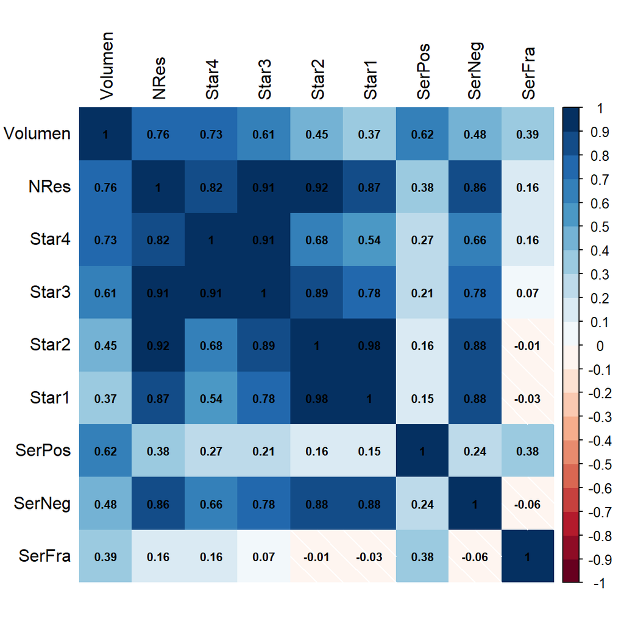

Figure 30: Matriz de Correlación para las variables de mayor colinealidad

```r
Colinealidad <- c('Volumen','NRes','Star4','Star3','Star2','Star1','SerPos','SerNeg','SerFra')
EPA[Colinealidad] %>% cor() %>% corrplot(method='shade', number.digits = 2, number.cex = 0.7,tl.col='black',
                                       tl.cex=1,col = COL2('RdBu', 20), addCoef.col = 'black')
```

Dados los criterios y la matriz de correlación se hacen dos propuestas:

- PROPUESTA 1:
  - Descartamos la variable *NRes* ya que muestra una alta colinealidad con todas las variables *StarX*.
  - Entre las variables *StarX*, nos quedamos las que mejor correlan con la variable objetivo y, a su vez, no tenga alta colinealidad entre ellas. Estas son *Star4* y *Star2*. Por lo tanto, descartamos *Star3* y *Star1*.
  - Se descarta la variable *SerNeg* ya que es colineal con *Star2* y tiene una correlación parecida con la variable objetivo.

Con estos cambios, la nueva matriz de correlación resulta:

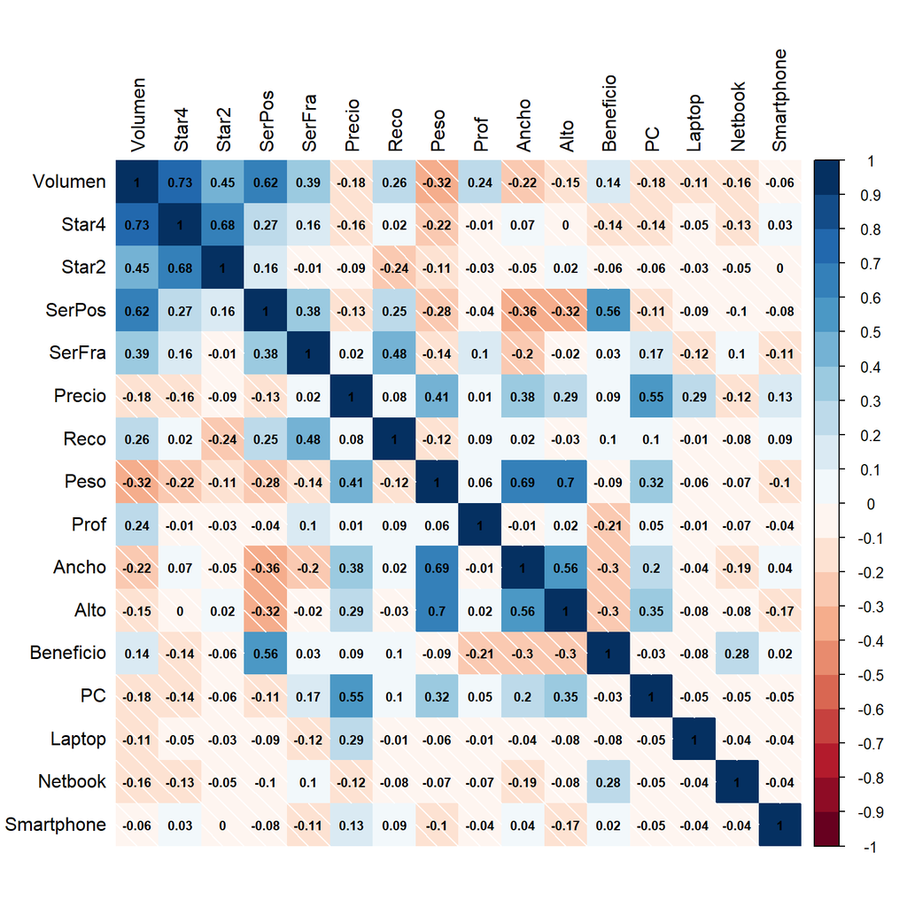

Figure 31: Matriz de Correlación para la Propuesta 1.

```r
#Variables Propuesta 1
Propuesta1 <- c('Volumen','Star4','Star2','SerPos','SerFra','Precio','Reco','Peso','Prof','Ancho','Alto',
                  'Beneficio','PC','Laptop','Netbook','Smartphone')
#Añadirmos la nueva variable a la lista
EPA[Propuesta1] %>% cor() %>% corrplot(method='shade', number.digits = 2, number.cex = 0.7,tl.col='black',tl.cex=1,col = COL2('RdBu', 20), addCoef.col = 'black')
```

- PROPUESTA 2:
  - Descartamos las variables *Star3* y *Star1* por la misma razón que en la anterior propuesta.
  - Descartamos la variable *SerNeg* porque es colineal con *NRes*.
  - A diferencia de la primera propuesta, mantenemos *NRes* ya que correla algo mejor con la variable objetivo. Sin embargo, y a pesar de que existe colinealidad con *Star4* y *Star2*, no descartamos estas variables. En su lugar, creamos una nueva resultado de combinar estas dos a través de una regresión lineal.

```r
#Regresión lineal con Star4 y Star2
lm_model <- train(Volumen ~ Star4 + Star2, EPA, method = "lm")
#Tomamos coeficientes de la regresión
lm_coef <- summary(lm_model)$coefficients
#Creamos variable reseña media ponderada
EPA$Star_lm <- lm_coef[2]*EPA$Star4+lm_coef[3]*EPA$Star2
```

Y visualizamos la matriz de correlación resultante para esta segunda propuesta.

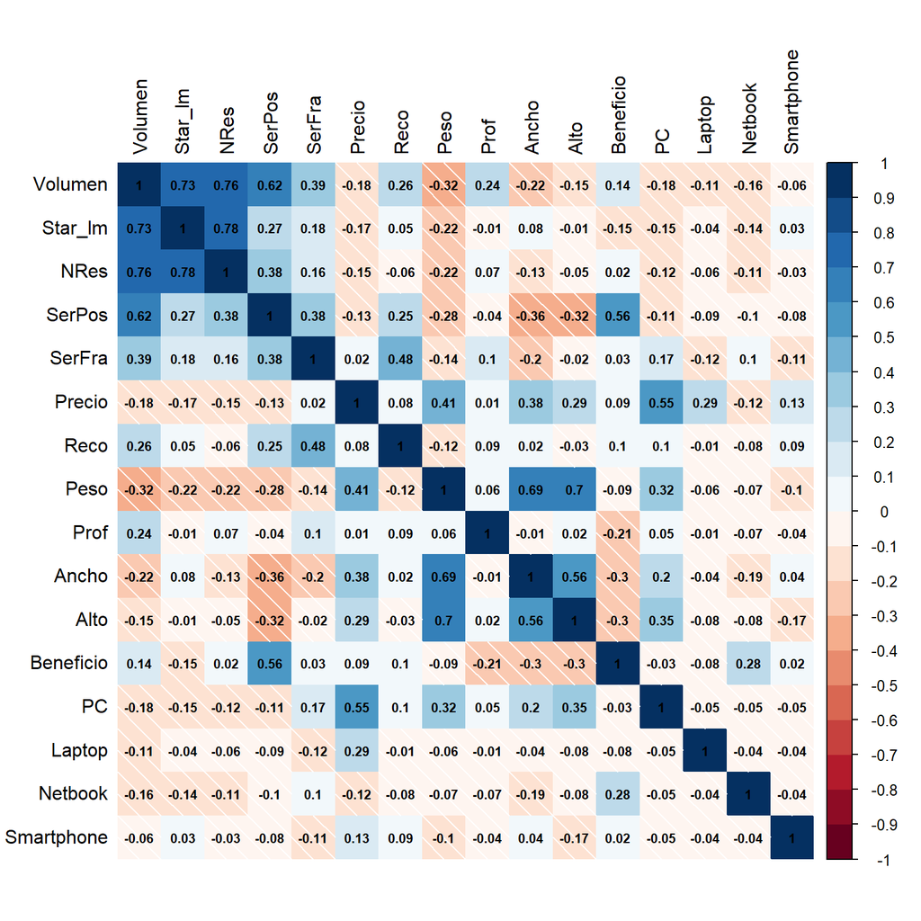

Figure 32: Matriz de Correlación para la Propuesta 2.

```r
Propuesta2 <- c('Volumen','Star_lm','NRes','SerPos','SerFra','Precio','Reco','Peso','Prof','Ancho','Alto',
                  'Beneficio','PC','Laptop','Netbook','Smartphone')
#Añadirmos la nueva variable a la lista
EPA[Propuesta2] %>% cor() %>% corrplot(method='shade', number.digits = 2, number.cex = 0.7,tl.col='black',tl.cex=1,col = COL2('RdBu', 20), addCoef.col = 'black')
```